# Acheta Desiccation

- Show All Code
- Hide All Code
- View Source

Guts and gonads

Author

Affiliation

Jacinta Kong

Department of Biology, Carleton Univeristy, Canada

Published

October 8, 2026

# 1 Aim

To portion out tissue water content into gut and gonad water content and determine if crickets are storing water in their gut lumen.

# 2 Setup

# 3 Load data

Calculate:

- Staring mass
- Transfer mass
- Whole animal wet mass (end mass)
- Wet carcass mass
- Wet gut mass
- Wet gonad mass
- Dry carcass mass
- Dry gut mass
- Dry gonad mass

```r
gg_data <- read_excel("data/Desiccation 2025/guts and gonads/GutsAndGonads_massdata.xlsx") %>%
  mutate(Whole_animal_wet_mass = wet_whole_body - carcass_tube,
         Start_mass = case_when(Time_treatment == 0 ~ Whole_animal_wet_mass,
                              .default = start_cricket - start_container),
         Rehydrated_transfer_mass = ifelse(Time == 24, transfer_cricket - transfer_container, NA),
         wet_carcass_mass  = wet_carcass - carcass_tube,
         wet_gut_mass = wet_gut - gut_tube,
         wet_gonad_mass = wet_gonad - gonad_tube,
         dry_carcass_mass  = dry_carcass - carcass_tube,
         dry_gut_mass = dry_gut - gut_tube,
         dry_gonad_mass = dry_gonad - gonad_tube,
         total_dry_mass = dry_carcass_mass + dry_gut_mass + dry_gonad_mass,
         Percent_change = case_when(Time == 0 ~ NA,
                                    Time == 24 ~ 100 - (Rehydrated_transfer_mass / Start_mass) * 100,
                              .default = 100 - (Whole_animal_wet_mass / Start_mass) * 100),
         Desiccation_time = ifelse(Time == 24, 18, Time),
         Total_water_content = ((Start_mass - total_dry_mass) / Start_mass) * 100,
         # Water lost during desiccation (%)
         Relative_water_loss = (Percent_change /  Total_water_content) * 100,
         # Calculate water loss rates
         Mass_change_rate = ifelse(Time == 0, NA, Percent_change / Desiccation_time)) # %/h)

# Calculate water content
gg_data <- gg_data %>%
  mutate(
    # Total amount of water in body
    Body_water = Start_mass - total_dry_mass,
    # Water lost during desiccation
    Lost_water = Start_mass - Whole_animal_wet_mass,
    # Water in all tissues post-desiccation
    Tissue_water = Whole_animal_wet_mass - total_dry_mass,
    carcass_water = wet_carcass_mass - dry_carcass_mass,
    gut_water = wet_gut_mass - dry_gut_mass,
    gonad_water = wet_gonad_mass - dry_gonad_mass,
    haem_water = Tissue_water - carcass_water - gut_water - gonad_water)

# Calculate proportion relative to total amount of body water
gg_data <- gg_data %>%
  mutate(
    # Water lost during desiccation
    Desiccation_water_prop = -((Lost_water / Body_water) * 100),
    # Water in tissue post-desiccation
    Tissue_prop =  ((Tissue_water / Body_water) * 100),
    carcass_water_prop = (carcass_water / Body_water) * 100,
    gut_water_prop = (gut_water / Body_water) * 100,
    gonad_water_prop = (gonad_water / Body_water) * 100,
    haem_water_prop = (haem_water / Body_water) * 100)

# Remove 182 outlier constipated male
gg_data <- filter(gg_data, Cricket_ID != 182)

# Removed starved control group
gg_data <- filter(gg_data, Time_treatment != "0_starved")
```

```r
# Standardise changes relative to controls
baseline <- gg_data %>%
  group_by(Sex) %>%
  filter(Time == 0) %>%
  summarise(mean_tissue = mean(Tissue_prop),
            mean_carcass = mean(carcass_water_prop),
            mean_gut = mean(gut_water_prop),
            mean_gonad = mean(gonad_water_prop),
            mean_haem = mean(haem_water_prop)) %>%
  data.frame(row.names  = c("F", "M"))

gg_data <- gg_data %>%
  mutate(diff_tissue = ifelse(Sex == "Female", Tissue_prop - baseline["F",2],
                             Tissue_prop - baseline["M",2]),
         diff_carcass = ifelse(Sex == "Female", carcass_water_prop - baseline["F","mean_carcass"], carcass_water_prop - baseline["M","mean_carcass"]),
         diff_gut = ifelse(Sex == "Female", gut_water_prop - baseline["F","mean_gut"], gut_water_prop - baseline["M","mean_gut"]),
         diff_gonad = ifelse(Sex == "Female", gonad_water_prop - baseline["F","mean_gonad"], gonad_water_prop - baseline["M","mean_gonad"]),
         diff_haem = ifelse(Sex == "Female", haem_water_prop - baseline["F","mean_haem"],
                             haem_water_prop - baseline["M","mean_haem"]))
```

Derive:

- Water content (mg)
- Total water content (mg); sum of all water content
- Haemolymph content (mg); remaining water

```r
rehydration_guts <- gg_data %>%
  filter(Time == 24) %>%
  mutate(Percent_change = 100 - (Rehydrated_transfer_mass / Start_mass) * 100,
         Percent_change_recovery = (Whole_animal_wet_mass / Start_mass) * 100) %>%
  select(Cricket_ID, Sex, Time_treatment, Percent_change, Percent_change_recovery) %>%
  mutate(Start_Percent = 100,
         Percent_change = 100 - Percent_change) %>%
  pivot_longer(contains("Percent"), names_to = "Timepoint", values_to = "Change") %>%
  mutate(Experiment = "Guts",
    Timepoint = factor(Timepoint, levels = c("Start_Percent", "Percent_change", "Percent_change_recovery")))

save(gg_data, rehydration_guts, file = "data/Desiccation 2025/guts.Rdata")
```

```r
Percent_change_mean <- gg_data %>%
  group_by(Time, Sex) %>%
  summarise(n = n(),
            mean = mean(Percent_change),
            se = sd(Percent_change) / sqrt(n()),
            cv = (sd(Percent_change) / mean) * 100)
knitr::kable(Percent_change_mean, digits = 3)
```

| Time | Sex | n | mean | se | cv |
| --- | --- | --- | --- | --- | --- |
| 0 | Female | 8 | NA | NA | NA |
| 0 | Male | 8 | NA | NA | NA |
| 3 | Female | 8 | 2.849 | 0.591 | 58.671 |
| 3 | Male | 8 | 3.919 | 0.476 | 34.328 |
| 6 | Female | 8 | 3.357 | 0.369 | 31.060 |
| 6 | Male | 8 | 7.907 | 0.976 | 34.909 |
| 18 | Female | 8 | 10.625 | 1.233 | 32.815 |
| 18 | Male | 8 | 12.686 | 1.253 | 27.929 |
| 24 | Female | 8 | 7.841 | 0.711 | 25.630 |
| 24 | Male | 8 | 16.099 | 0.983 | 17.272 |

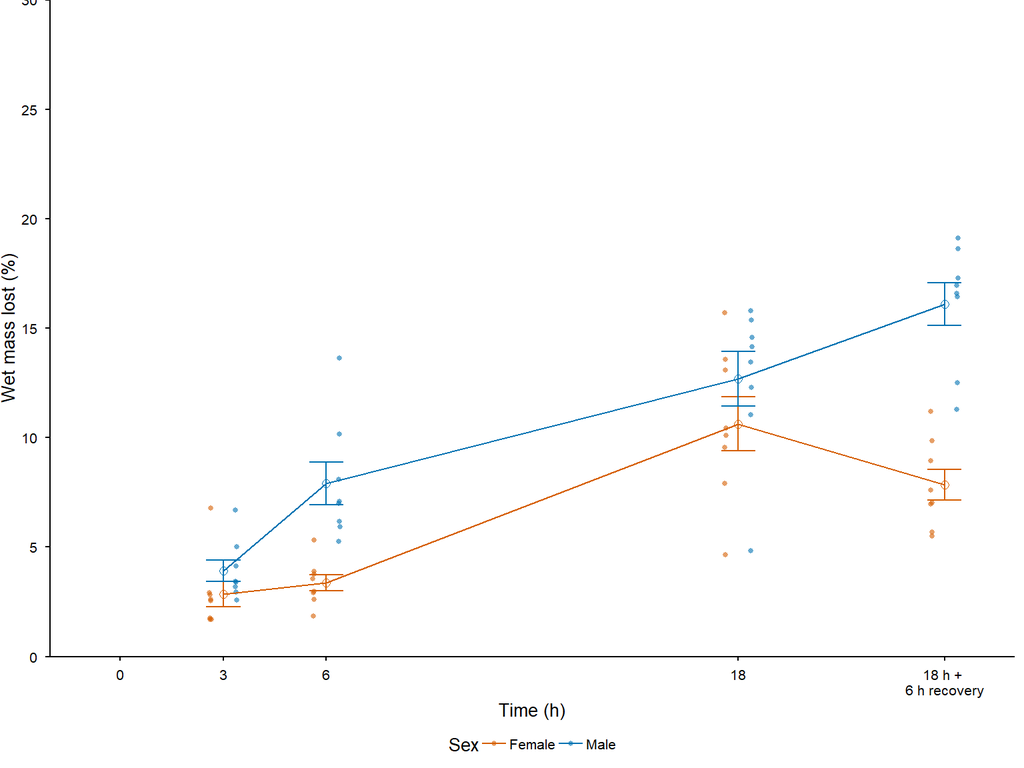

```r
ggplot() +
  geom_point(data = gg_data, aes(Time, Percent_change, shape = Sex, colour = Sex), position = position_jitterdodge(jitter.height = 0, jitter.width = 0.1, dodge = 1.5), alpha = 0.6, stroke = NA) +
  geom_line(data = Percent_change_mean, aes(Time, mean, colour = Sex), linewidth = 0.5) +
  geom_point(data = Percent_change_mean, aes(Time, mean, colour = Sex),
             size = 2, shape = 1, show.legend = FALSE) +
  geom_errorbar(data = Percent_change_mean, aes(Time, ymin = mean - se, ymax = mean + se,
                                     colour = Sex), width = 1, linewidth = 0.5) +
  scale_colour_manual(values = sex_pal) +
  scale_shape_manual(values = sex_point) +
  scale_y_continuous(name = "Wet mass lost (%)", limits = c(0, 30), expand = c(0,0), breaks = seq(0, 150, 5)) +
  scale_x_continuous(name = "Time (h)", breaks = c(0, 3, 6, 18, 24), labels = c("0", "3", "6", "18", "18 h + \n6 h recovery"))
```

# 4 Relative difference in body water

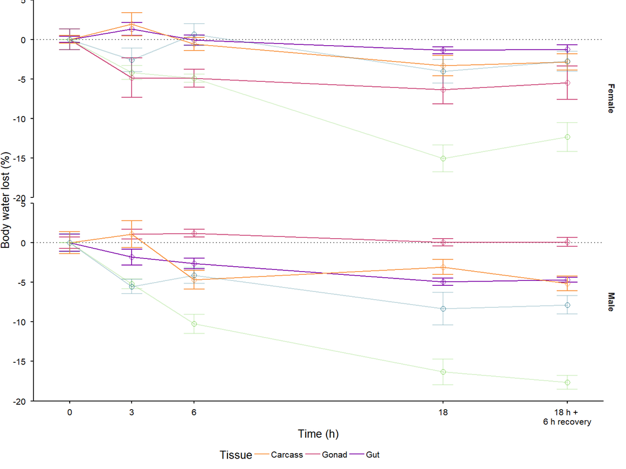

```r
diff_water <- gg_data %>%
  group_by(Time, Sex) %>%
  summarise(.groups = "drop",
            n = n(),
            # Tissue
            mean_tissue = mean(diff_tissue),
            se_tissue = sd(diff_tissue) / sqrt(n()),
            # Gut
            mean_gut = mean(diff_gut),
            se_gut = sd(diff_gut) / sqrt(n()),
            # Gonad
            mean_gonad = mean(diff_gonad),
            se_gonad = sd(diff_gonad) / sqrt(n()),
            # carcass
            mean_carcass = mean(diff_carcass),
            se_carcass = sd(diff_carcass) / sqrt(n()),
            # Haem
            mean_haem = mean(diff_haem),
            se_haem = sd(diff_haem) / sqrt(n()),
            # Total loss
            mean_loss = mean(Desiccation_water_prop),
            se_loss =  sd(Desiccation_water_prop) / sqrt(n()))

diff_pal <- viridis::viridis(4, begin = 0.75, end = 0, option = "C")
diff_pal2 <- viridis::viridis(3, begin = 0.8, end = 0, option = "D")

p_diff_tissues <- ggplot(gg_data, aes(x = Time)) +
  geom_hline(yintercept = 0, linetype = 3, colour = "grey30") +
  # gut
  # geom_point(aes(y = diff_gut, colour = "Gut"), position = position_jitter(height = 0, width = 0.1), alpha = 0.6, stroke = NA) +
  geom_line(aes(y = mean_gut, colour = "Gut"), data = diff_water, linewidth = 0.5) +
  geom_point(aes(y = mean_gut, colour = "Gut"), data = diff_water, size = 2, shape = 1, show.legend = FALSE) +
  geom_errorbar(data = diff_water, aes(ymin = mean_gut - se_gut, ymax = mean_gut + se_gut, colour = "Gut"), width = 1, linewidth = 0.5) +
  # gonad
  # geom_point(aes(y = diff_gonad, colour = "Gonad"), position = position_jitter(height = 0, width = 0.1), alpha = 0.6, stroke = NA) +
  geom_line(aes(y = mean_gonad, colour = "Gonad"), data = diff_water, linewidth = 0.5) +
  geom_point(aes(y = mean_gonad, colour = "Gonad"), data = diff_water, size = 2, shape = 1, show.legend = FALSE) +
  geom_errorbar(data = diff_water, aes(ymin = mean_gonad - se_gonad, ymax = mean_gonad + se_gonad, colour = "Gonad"), width = 1, linewidth = 0.5) +
  # carcass
  # geom_point(aes(y = diff_carcass, colour = "Carcass"), position = position_jitter(height = 0, width = 0.1), alpha = 0.6, stroke = NA) +
  geom_line(aes(y = mean_carcass, colour = "Carcass"), data = diff_water, linewidth = 0.5) +
  geom_point(aes(y = mean_carcass, colour = "Carcass"), data = diff_water, size = 2, shape = 1, show.legend = FALSE) +
  geom_errorbar(data = diff_water, aes(ymin = mean_carcass - se_carcass, ymax = mean_carcass + se_carcass, colour = "Carcass"), width = 1, linewidth = 0.5) +
  # total
  # geom_point(aes(y = Desiccation_water_prop, colour = "Total loss"), position = position_jitter(height = 0, width = 0.1), alpha = 0.3, stroke = NA, show.legend = FALSE) +
  geom_line(aes(y = mean_loss, colour = "Total loss"), data = diff_water, linewidth = 0.5, alpha = 0.3, show.legend = FALSE) +
  geom_point(aes(y = mean_loss, colour = "Total loss"), data = diff_water, size = 2, shape = 1, show.legend = FALSE) +
  geom_errorbar(data = diff_water, aes(ymin = mean_loss - se_loss, ymax = mean_loss + se_loss, colour = "Total loss"), width = 1, linewidth = 0.5, alpha = 0.3, show.legend = FALSE) +
  # haem
  # geom_point(aes(y = diff_haem, colour = "Haemolymph"), position = position_jitter(height = 0, width = 0.1), alpha = 0.3, stroke = NA, show.legend = FALSE) +
  geom_line(aes(y = mean_haem, colour = "Haemolymph"), data = diff_water, linewidth = 0.5, alpha = 0.3, show.legend = FALSE) +
  geom_point(aes(y = mean_haem, colour = "Haemolymph"), data = diff_water, size = 2, shape = 1, show.legend = FALSE) +
  geom_errorbar(data = diff_water, aes(ymin = mean_haem - se_haem, ymax = mean_haem + se_haem, colour = "Haemolymph"), width = 1, linewidth = 0.5, alpha = 0.3, show.legend = FALSE) +
  # # tissue
  # geom_point(aes(y = diff_tissue, colour = "tissue"), position = position_jitter(height = 0, width = 0.1), alpha = 0.6, stroke = NA) +
  # geom_line(aes(y = mean_tissue, colour = "tissue"), data = diff_water, linewidth = 0.5) +
  # geom_point(aes(y = mean_tissue, colour = "tissue"), data = diff_water, size = 2, shape = 1, show.legend = FALSE) +
  # geom_errorbar(data = diff_water, aes(ymin = mean_tissue - se_tissue, ymax = mean_tissue + se_tissue, colour = "tissue"), width = 1, linewidth = 0.5) +
  scale_colour_manual(name = "Tissue", values = c("Gut" = diff_pal[3], "Gonad" = diff_pal[2], "Carcass" = diff_pal[1], "Total loss" = diff_pal2[1],"Haemolymph" = diff_pal2[2]), labels = c("Carcass", "Gonad", "Gut", "","")) +
  scale_y_continuous(name = "Body water lost (%)", limits = c(-20, 5), expand = c(0,0), breaks = seq(-50, 30, 5)) +
  scale_x_continuous(name = "Time (h)", breaks = c(0, 3, 6, 18, 24), labels = c("0", "3", "6", "18", "18 h + \n6 h recovery")) +
facet_grid(Sex~.)

p_diff_tissues
```

Effect of sex but no interaction

```r
anova(lm(diff_gut ~ Time_treatment + Sex, gg_data))
```

```
Analysis of Variance Table

Response: diff_gut
               Df Sum Sq Mean Sq F value       Pr(>F)
Time_treatment  4 139.90  34.975  8.7013 0.0000082027 ***
Sex             1 129.78 129.783 32.2885 0.0000002477 ***
Residuals      74 297.44   4.019
---
Signif. codes:  0 '***' 0.001 '**' 0.01 '*' 0.05 '.' 0.1 ' ' 1
```

```r
anova(lm(diff_gonad ~ Time_treatment + Sex, gg_data))
```

```
Analysis of Variance Table

Response: diff_gonad
               Df  Sum Sq Mean Sq F value       Pr(>F)
Time_treatment  4   92.88   23.22  1.4968       0.2119
Sex             1  457.63  457.63 29.4998 0.0000006822 ***
Residuals      74 1147.97   15.51
---
Signif. codes:  0 '***' 0.001 '**' 0.01 '*' 0.05 '.' 0.1 ' ' 1
```

```r
anova(lm(diff_carcass ~ Time_treatment + Sex, gg_data))
```

```
Analysis of Variance Table

Response: diff_carcass
               Df Sum Sq Mean Sq F value     Pr(>F)
Time_treatment  4 343.86  85.964  7.7634 0.00002794 ***
Sex             1  39.74  39.738  3.5887    0.06208 .
Residuals      74 819.40  11.073
---
Signif. codes:  0 '***' 0.001 '**' 0.01 '*' 0.05 '.' 0.1 ' ' 1
```

```r
pairs(emmeans(lm(diff_gut ~ Time_treatment + Sex, gg_data), ~ Time_treatment), adjust = "Tukey")
```

```
 contrast        estimate    SE df t.ratio p.value
 0 - 18             3.158 0.709 74   4.455  0.0003
 0 - 24_starved     2.981 0.709 74   4.206  0.0007
 0 - 3              0.257 0.709 74   0.363  0.9962
 0 - 6              1.359 0.709 74   1.917  0.3173
 18 - 24_starved   -0.177 0.709 74  -0.249  0.9991
 18 - 3            -2.901 0.709 74  -4.092  0.0010
 18 - 6            -1.799 0.709 74  -2.538  0.0933
 24_starved - 3    -2.724 0.709 74  -3.843  0.0023
 24_starved - 6    -1.622 0.709 74  -2.288  0.1602
 3 - 6              1.102 0.709 74   1.554  0.5310

Results are averaged over the levels of: Sex
P value adjustment: tukey method for comparing a family of 5 estimates
```

```r
pairs(emmeans(lm(diff_gonad ~ Time_treatment + Sex, gg_data), ~ Time_treatment), adjust = "Tukey")
```

```
 contrast        estimate   SE df t.ratio p.value
 0 - 18             3.157 1.39 74   2.267  0.1673
 0 - 24_starved     2.683 1.39 74   1.927  0.3126
 0 - 3              1.875 1.39 74   1.347  0.6632
 0 - 6              1.854 1.39 74   1.332  0.6726
 18 - 24_starved   -0.474 1.39 74  -0.340  0.9970
 18 - 3            -1.282 1.39 74  -0.920  0.8881
 18 - 6            -1.303 1.39 74  -0.936  0.8821
 24_starved - 3    -0.808 1.39 74  -0.580  0.9776
 24_starved - 6    -0.829 1.39 74  -0.595  0.9754
 3 - 6             -0.021 1.39 74  -0.015  1.0000

Results are averaged over the levels of: Sex
P value adjustment: tukey method for comparing a family of 5 estimates
```

```r
pairs(emmeans(lm(diff_carcass ~ Time_treatment + Sex, gg_data), ~ Time_treatment), adjust = "Tukey")
```

```
 contrast        estimate   SE df t.ratio p.value
 0 - 18             3.193 1.18 74   2.714  0.0614
 0 - 24_starved     4.000 1.18 74   3.400  0.0093
 0 - 3             -1.501 1.18 74  -1.276  0.7069
 0 - 6              2.619 1.18 74   2.226  0.1817
 18 - 24_starved    0.808 1.18 74   0.687  0.9588
 18 - 3            -4.693 1.18 74  -3.989  0.0014
 18 - 6            -0.574 1.18 74  -0.488  0.9883
 24_starved - 3    -5.501 1.18 74  -4.676  0.0001
 24_starved - 6    -1.382 1.18 74  -1.174  0.7658
 3 - 6              4.119 1.18 74   3.501  0.0069

Results are averaged over the levels of: Sex
P value adjustment: tukey method for comparing a family of 5 estimates
```

```r
emmeans(lm(diff_gut ~ Time_treatment + Sex, gg_data), ~ Time_treatment) %>%
  contrast(method = "trt.vs.ctrl", ref = 1)
```

```
 contrast       estimate    SE df t.ratio p.value
 18 - 0           -3.158 0.709 74  -4.455  0.0001
 24_starved - 0   -2.981 0.709 74  -4.206  0.0003
 3 - 0            -0.257 0.709 74  -0.363  0.9676
 6 - 0            -1.359 0.709 74  -1.917  0.1843

Results are averaged over the levels of: Sex
P value adjustment: dunnettx method for 4 tests
```

```r
emmeans(lm(diff_gonad ~ Time_treatment + Sex, gg_data), ~ Time_treatment) %>%
  contrast(method = "trt.vs.ctrl", ref = 1)
```

```
 contrast       estimate   SE df t.ratio p.value
 18 - 0            -3.16 1.39 74  -2.267  0.0884
 24_starved - 0    -2.68 1.39 74  -1.927  0.1810
 3 - 0             -1.88 1.39 74  -1.347  0.4673
 6 - 0             -1.85 1.39 74  -1.332  0.4765

Results are averaged over the levels of: Sex
P value adjustment: dunnettx method for 4 tests
```

```r
emmeans(lm(diff_carcass ~ Time_treatment + Sex, gg_data), ~ Time_treatment) %>%
  contrast(method = "trt.vs.ctrl", ref = 1)
```

```
 contrast       estimate   SE df t.ratio p.value
 18 - 0            -3.19 1.18 74  -2.714  0.0296
 24_starved - 0    -4.00 1.18 74  -3.400  0.0041
 3 - 0              1.50 1.18 74   1.276  0.5114
 6 - 0             -2.62 1.18 74  -2.226  0.0970

Results are averaged over the levels of: Sex
P value adjustment: dunnettx method for 4 tests
```

- Gonad does not change over time but has the largest differences
- Gut and carcass changes over time

# 5 Carcass

```r
carcass_water_mean <- gg_data %>%
  group_by(Time, Sex) %>%
  summarise(n = n(),
            mean = mean(carcass_water),
            se = sd(carcass_water) / sqrt(n()),
            cv = (sd(carcass_water) / mean) * 100)
knitr::kable(carcass_water_mean, digits = 3)
```

| Time | Sex | n | mean | se | cv |
| --- | --- | --- | --- | --- | --- |
| 0 | Female | 8 | 167.631 | 9.302 | 15.695 |
| 0 | Male | 8 | 126.955 | 6.552 | 14.598 |
| 3 | Female | 8 | 147.558 | 7.966 | 15.270 |
| 3 | Male | 8 | 122.269 | 4.857 | 11.236 |
| 6 | Female | 8 | 144.712 | 10.897 | 21.298 |
| 6 | Male | 8 | 120.179 | 7.878 | 18.541 |
| 18 | Female | 8 | 148.978 | 4.691 | 8.906 |
| 18 | Male | 8 | 121.030 | 9.155 | 21.395 |
| 24 | Female | 8 | 144.319 | 8.832 | 17.309 |
| 24 | Male | 8 | 120.206 | 4.623 | 10.877 |

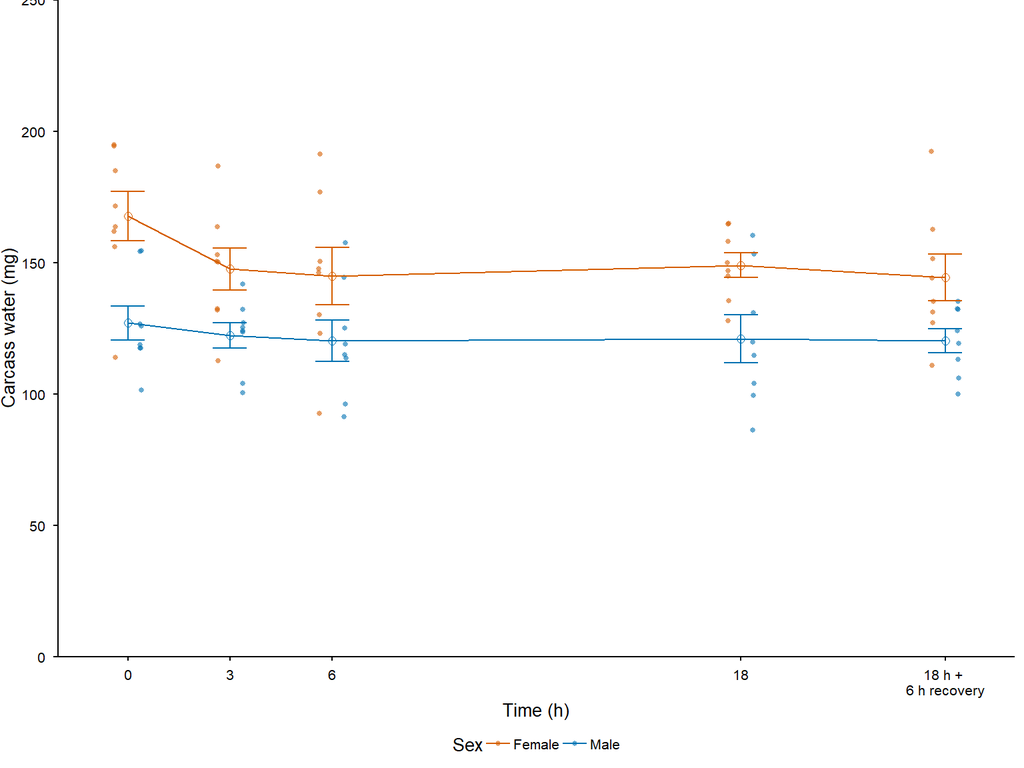

```r
ggplot() +
  geom_point(data = gg_data, aes(Time, carcass_water, shape = Sex, colour = Sex), alpha = 0.6, stroke = NA, position = position_jitterdodge(jitter.height = 0, jitter.width = 0.1, dodge = 1.5)) +
  geom_line(data = carcass_water_mean, aes(Time, mean, colour = Sex), linewidth = 0.5) +
  geom_point(data = carcass_water_mean, aes(Time, mean, colour = Sex),
             size = 2, shape = 1, show.legend = FALSE) +
  geom_errorbar(data = carcass_water_mean, aes(Time, ymin = mean - se, ymax = mean + se,
                                     colour = Sex), width = 1, linewidth = 0.5) +
  scale_colour_manual(values = sex_pal) +
  scale_shape_manual(values = sex_point) +
  scale_y_continuous(name = "Carcass water (mg)", limits = c(0, 250), expand = c(0,0), breaks = seq(0, 250, 50)) +
  scale_x_continuous(name = "Time (h)", breaks = c(0, 3, 6, 18, 24), labels = c("0", "3", "6", "18", "18 h + \n6 h recovery"))
```

```r
carcass_water_prop_mean <- gg_data %>%
  group_by(Time, Sex) %>%
  summarise(n = n(),
            mean = mean(carcass_water_prop),
            se = sd(carcass_water_prop) / sqrt(n()),
            cv = (sd(carcass_water_prop) / mean) * 100)
knitr::kable(carcass_water_prop_mean, digits = 3)
```

| Time | Sex | n | mean | se | cv |
| --- | --- | --- | --- | --- | --- |
| 0 | Female | 8 | 41.085 | 0.493 | 3.391 |
| 0 | Male | 8 | 52.756 | 1.401 | 7.511 |
| 3 | Female | 8 | 43.007 | 1.459 | 9.596 |
| 3 | Male | 8 | 53.836 | 1.683 | 8.843 |
| 6 | Female | 8 | 40.515 | 0.826 | 5.769 |
| 6 | Male | 8 | 48.088 | 1.186 | 6.973 |
| 18 | Female | 8 | 37.778 | 1.270 | 9.510 |
| 18 | Male | 8 | 49.678 | 0.966 | 5.502 |
| 24 | Female | 8 | 38.254 | 1.019 | 7.536 |
| 24 | Male | 8 | 47.587 | 0.925 | 5.497 |

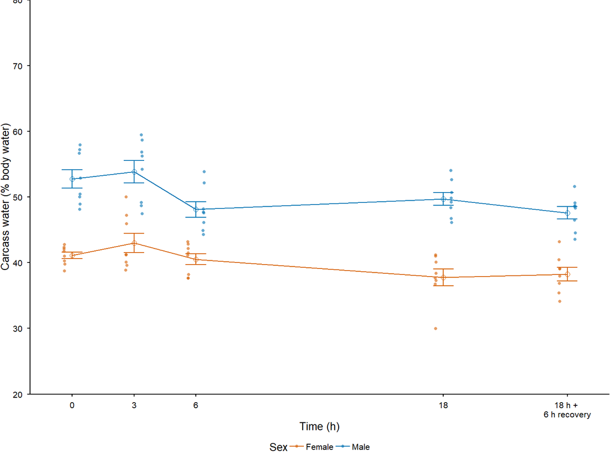

```r
p_carcass <- ggplot() +
  geom_point(data = gg_data, aes(Time, carcass_water_prop, shape = Sex, colour = Sex), position = position_jitterdodge(jitter.height = 0, jitter.width = 0.1, dodge = 1.5), alpha = 0.6, stroke = NA) +
  geom_line(data = carcass_water_prop_mean, aes(Time, mean, colour = Sex), linewidth = 0.5) +
  geom_point(data = carcass_water_prop_mean, aes(Time, mean, colour = Sex),
             size = 2, shape = 1, show.legend = FALSE) +
  geom_errorbar(data = carcass_water_prop_mean, aes(Time, ymin = mean - se, ymax = mean + se,
                                     colour = Sex), width = 1, linewidth = 0.5) +
  scale_colour_manual(values = sex_pal) +
  scale_shape_manual(values = sex_point) +
  scale_y_continuous(name = "Carcass water (% body water)", limits = c(20, 80), expand = c(0,0), breaks = seq(0, 150, 10)) +
  scale_x_continuous(name = "Time (h)", breaks = c(0, 3, 6, 18, 24), labels = c("0", "3", "6", "18", "18 h + \n6 h recovery"))

p_carcass
```

There is no interaction.

```r
carcass_mod <- lm(carcass_water_prop ~ Time_treatment + Sex, data = gg_data[gg_data$Time_treatment!="0_starved",])

anova(carcass_mod)
```

```
Analysis of Variance Table

Response: carcass_water_prop
               Df  Sum Sq Mean Sq  F value                Pr(>F)
Time_treatment  4  343.86   85.96   7.7634            0.00002794 ***
Sex             1 2105.80 2105.80 190.1752 < 0.00000000000000022 ***
Residuals      74  819.40   11.07
---
Signif. codes:  0 '***' 0.001 '**' 0.01 '*' 0.05 '.' 0.1 ' ' 1
```

```r
pairs(emmeans(carcass_mod, ~ Time_treatment), adjust = "Tukey") %>%
  broom::tidy() %>%
  filter(adj.p.value <= 0.05)
```

```
# A tibble: 4 × 8
  term           contrast       null.value  estimate std.error    df statistic
  <chr>          <chr>               <dbl>     <dbl>     <dbl> <dbl>     <dbl>
1 Time_treatment 0 - 24_starved          0  4.000388  1.176486    74  3.400285
2 Time_treatment 18 - 3                  0 -4.693315  1.176486    74 -3.989265
3 Time_treatment 24_starved - 3          0 -5.501116  1.176486    74 -4.675887
4 Time_treatment 3 - 6                   0  4.119360  1.176486    74  3.501410
   adj.p.value
         <dbl>
1 0.009329068
2 0.001414939
3 0.0001230852
4 0.006856923
```

```r
# Compare with 0 starved
emmeans(carcass_mod, ~ Time_treatment) %>%
  contrast(method = "trt.vs.ctrl", ref = "0")
```

```
 contrast       estimate   SE df t.ratio p.value
 18 - 0            -3.19 1.18 74  -2.714  0.0296
 24_starved - 0    -4.00 1.18 74  -3.400  0.0041
 3 - 0              1.50 1.18 74   1.276  0.5114
 6 - 0             -2.62 1.18 74  -2.226  0.0970

Results are averaged over the levels of: Sex
P value adjustment: dunnettx method for 4 tests
```

## 5.1 Relative carcass water

```r
gg_data <- gg_data %>%
  mutate(standard_carcass_water = ifelse(Sex == "Female",
                                        carcass_water/mean(gg_data[gg_data$Sex == "Female" & gg_data$Time == 0,]$carcass_water),
                                        carcass_water/mean(gg_data[gg_data$Sex == "Male" & gg_data$Time == 0,]$carcass_water)))

std_mean_carcass <- gg_data %>%
  group_by(Time_treatment, Sex, Time) %>%
  summarise(n = n(),
            mean = mean(standard_carcass_water),
            se = sd(standard_carcass_water) / sqrt(n()),
            cv = (sd(standard_carcass_water) / mean) * 100)
knitr::kable(std_mean_carcass, digits = 3)
```

| Time_treatment | Sex | Time | n | mean | se | cv |
| --- | --- | --- | --- | --- | --- | --- |
| 0 | Female | 0 | 8 | 1.000 | 0.055 | 15.695 |
| 0 | Male | 0 | 8 | 1.000 | 0.052 | 14.598 |
| 18 | Female | 18 | 8 | 0.889 | 0.028 | 8.906 |
| 18 | Male | 18 | 8 | 0.953 | 0.072 | 21.395 |
| 24_starved | Female | 24 | 8 | 0.861 | 0.053 | 17.309 |
| 24_starved | Male | 24 | 8 | 0.947 | 0.036 | 10.877 |
| 3 | Female | 3 | 8 | 0.880 | 0.048 | 15.270 |
| 3 | Male | 3 | 8 | 0.963 | 0.038 | 11.236 |
| 6 | Female | 6 | 8 | 0.863 | 0.065 | 21.298 |
| 6 | Male | 6 | 8 | 0.947 | 0.062 | 18.541 |

```r
rel_carcass <- ggplot() +
  geom_hline(yintercept = 1, linetype = 3, colour = "grey30") +
  geom_point(data = gg_data, aes(Time, standard_carcass_water, shape = Sex, colour = Sex), position = position_jitterdodge(jitter.height = 0, jitter.width = 0.1, dodge = 1.5), alpha = 0.6, stroke = NA) +
   # line for starved crickets
  geom_line(data = std_mean_carcass, aes(Time, mean, colour = Sex), linewidth = 0.5) +
  geom_point(data = std_mean_carcass, aes(Time, mean, colour = Sex),
             size = 2, shape = 1, show.legend = FALSE) +
  geom_errorbar(data = std_mean_carcass, aes(Time, ymin = mean - se, ymax = mean + se,
                                     colour = Sex), width = 1, linewidth = 0.5) +
  scale_colour_manual(values = sex_pal) +
  scale_shape_manual(values = sex_point) +
  scale_y_continuous(name = "Relative carcass water", limits = c(0.4, 1.6), expand = c(0,0), breaks = seq(0, 2, 0.2)) +
  scale_x_continuous(name = "Time (h)", breaks = c(0, 3, 6, 18, 24), labels = c("0", "3", "6", "18", "18 h + \n6 h recovery"))

rel_carcass_mod <- lm(standard_carcass_water ~ Time_treatment + Sex, data = gg_data)
# No interaction
anova(rel_carcass_mod)
```

```
Analysis of Variance Table

Response: standard_carcass_water
               Df  Sum Sq  Mean Sq F value  Pr(>F)
Time_treatment  4 0.10174 0.025435  1.2001 0.31799
Sex             1 0.08023 0.080229  3.7856 0.05549 .
Residuals      74 1.56829 0.021193
---
Signif. codes:  0 '***' 0.001 '**' 0.01 '*' 0.05 '.' 0.1 ' ' 1
```

```r
# Compare with 0 starved
emmeans(rel_carcass_mod, ~ Time_treatment) %>%
  contrast(method = "trt.vs.ctrl", ref = "0")
```

```
 contrast       estimate     SE df t.ratio p.value
 18 - 0          -0.0790 0.0515 74  -1.534  0.3580
 24_starved - 0  -0.0961 0.0515 74  -1.867  0.2028
 3 - 0           -0.0783 0.0515 74  -1.522  0.3649
 6 - 0           -0.0950 0.0515 74  -1.847  0.2108

Results are averaged over the levels of: Sex
P value adjustment: dunnettx method for 4 tests
```

```r
emmeans(rel_carcass_mod, ~ Time_treatment) %>%
  pairs(adjust = "Tukey")
```

```
 contrast         estimate     SE df t.ratio p.value
 0 - 18           0.078969 0.0515 74   1.534  0.5439
 0 - 24_starved   0.096113 0.0515 74   1.867  0.3439
 0 - 3            0.078327 0.0515 74   1.522  0.5518
 0 - 6            0.095049 0.0515 74   1.847  0.3552
 18 - 24_starved  0.017144 0.0515 74   0.333  0.9973
 18 - 3          -0.000642 0.0515 74  -0.012  1.0000
 18 - 6           0.016079 0.0515 74   0.312  0.9979
 24_starved - 3  -0.017786 0.0515 74  -0.346  0.9969
 24_starved - 6  -0.001065 0.0515 74  -0.021  1.0000
 3 - 6            0.016721 0.0515 74   0.325  0.9975

Results are averaged over the levels of: Sex
P value adjustment: tukey method for comparing a family of 5 estimates
```

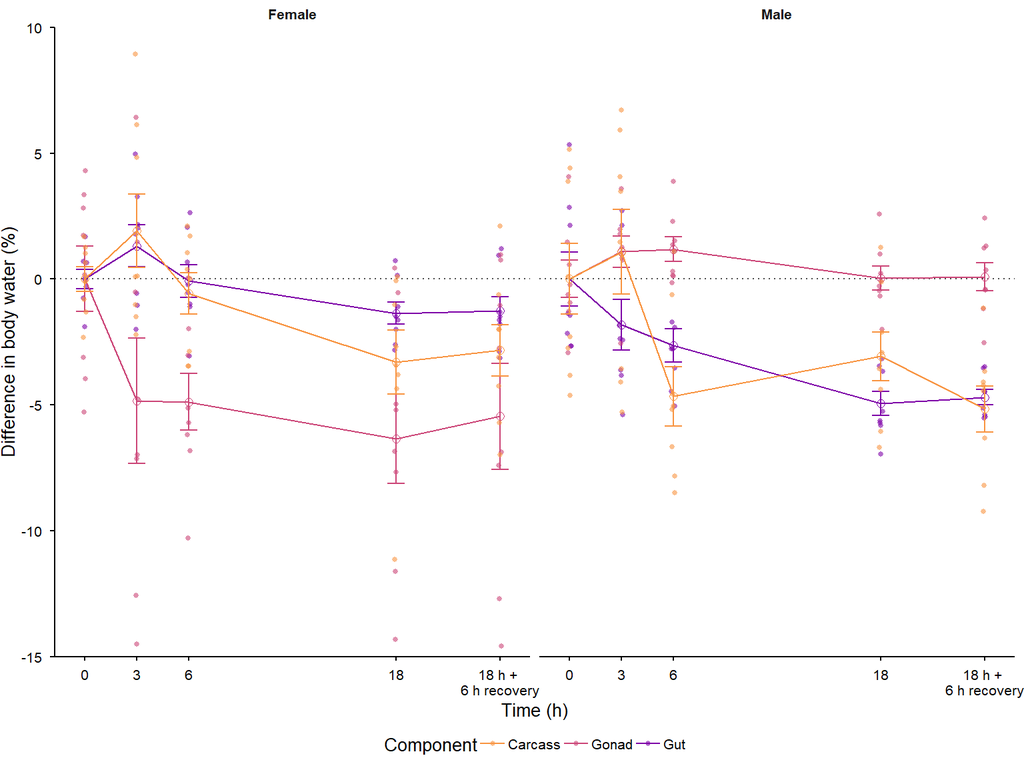

```r
diff_water <- gg_data %>%
  group_by(Time, Sex) %>%
  summarise(.groups = "drop",
            n = n(),
            # Tissue
            mean_tissue = mean(diff_tissue),
            se_tissue = sd(diff_tissue) / sqrt(n()),
            # Gut
            mean_gut = mean(diff_gut),
            se_gut = sd(diff_gut) / sqrt(n()),
            # Gonad
            mean_gonad = mean(diff_gonad),
            se_gonad = sd(diff_gonad) / sqrt(n()),
            # carcass
            mean_carcass = mean(diff_carcass),
            se_carcass = sd(diff_carcass) / sqrt(n()),
            # Haem
            mean_haem = mean(diff_haem),
            se_haem = sd(diff_haem) / sqrt(n()),
            # Total loss
            mean_loss = mean(Desiccation_water_prop),
            se_loss =  sd(Desiccation_water_prop) / sqrt(n()))

diff_pal <- viridis::viridis(4, begin = 0.75, end = 0, option = "C")

p_diff_tissues <- ggplot(gg_data, aes(x = Time)) +
  geom_hline(yintercept = 0, linetype = 3, colour = "grey30") +
  # gut
  geom_point(aes(y = diff_gut, colour = "Gut"), position = position_jitter(height = 0, width = 0.1), alpha = 0.6, stroke = NA) +
  geom_line(aes(y = mean_gut, colour = "Gut"), data = diff_water, linewidth = 0.5) +
  geom_point(aes(y = mean_gut, colour = "Gut"), data = diff_water, size = 2, shape = 1, show.legend = FALSE) +
  geom_errorbar(data = diff_water, aes(ymin = mean_gut - se_gut, ymax = mean_gut + se_gut, colour = "Gut"), width = 1, linewidth = 0.5) +
  # gonad
  geom_point(aes(y = diff_gonad, colour = "Gonad"), position = position_jitter(height = 0, width = 0.1), alpha = 0.6, stroke = NA) +
  geom_line(aes(y = mean_gonad, colour = "Gonad"), data = diff_water, linewidth = 0.5) +
  geom_point(aes(y = mean_gonad, colour = "Gonad"), data = diff_water, size = 2, shape = 1, show.legend = FALSE) +
  geom_errorbar(data = diff_water, aes(ymin = mean_gonad - se_gonad, ymax = mean_gonad + se_gonad, colour = "Gonad"), width = 1, linewidth = 0.5) +
  # carcass
  geom_point(aes(y = diff_carcass, colour = "Carcass"), position = position_jitter(height = 0, width = 0.1), alpha = 0.6, stroke = NA) +
  geom_line(aes(y = mean_carcass, colour = "Carcass"), data = diff_water, linewidth = 0.5) +
  geom_point(aes(y = mean_carcass, colour = "Carcass"), data = diff_water, size = 2, shape = 1, show.legend = FALSE) +
  geom_errorbar(data = diff_water, aes(ymin = mean_carcass - se_carcass, ymax = mean_carcass + se_carcass, colour = "Carcass"), width = 1, linewidth = 0.5) +
  # # total
  # geom_point(aes(y = Desiccation_water_prop, colour = "Total loss"), position = position_jitter(height = 0, width = 0.1), alpha = 0.6, stroke = NA) +
  # geom_line(aes(y = mean_loss, colour = "Total loss"), data = diff_water, linewidth = 0.5) +
  # geom_point(aes(y = mean_loss, colour = "Total loss"), data = diff_water, size = 2, shape = 1, show.legend = FALSE) +
  # geom_errorbar(data = diff_water, aes(ymin = mean_loss - se_loss, ymax = mean_loss + se_loss, colour = "Total loss"), width = 1, linewidth = 0.5) +
  #   # haem
  # geom_point(aes(y = diff_haem, colour = "haem"), position = position_jitter(height = 0, width = 0.1), alpha = 0.6, stroke = NA) +
  # geom_line(aes(y = mean_haem, colour = "haem"), data = diff_water, linewidth = 0.5) +
  # geom_point(aes(y = mean_haem, colour = "haem"), data = diff_water, size = 2, shape = 1, show.legend = FALSE) +
  # # geom_errorbar(data = diff_water, aes(ymin = mean_haem - se_haem, ymax = mean_haem + se_haem, colour = "haem"), width = 1, linewidth = 0.5) +
  #   # tissue
  # geom_point(aes(y = diff_tissue, colour = "tissue"), position = position_jitter(height = 0, width = 0.1), alpha = 0.6, stroke = NA) +
  # geom_line(aes(y = mean_tissue, colour = "tissue"), data = diff_water, linewidth = 0.5) +
  # geom_point(aes(y = mean_tissue, colour = "tissue"), data = diff_water, size = 2, shape = 1, show.legend = FALSE) +
  # geom_errorbar(data = diff_water, aes(ymin = mean_tissue - se_tissue, ymax = mean_tissue + se_tissue, colour = "tissue"), width = 1, linewidth = 0.5) +
  # Theme
  scale_colour_manual(name = "Component", values = c("Gut" = diff_pal[3], "Gonad" = diff_pal[2], "Carcass" = diff_pal[1], "Total loss" = diff_pal[4])) +
  scale_y_continuous(name = "Difference in body water (%)", limits = c(-15, 10), expand = c(0,0), breaks = seq(-50, 30, 5)) +
  scale_x_continuous(name = "Time (h)", breaks = c(0, 3, 6, 18, 24), labels = c("0", "3", "6", "18", "18 h + \n6 h recovery")) +
facet_grid(~Sex)

p_diff_tissues
```

```r
anova(lm(diff_gut ~ Time_treatment + Sex, gg_data))
```

```
Analysis of Variance Table

Response: diff_gut
               Df Sum Sq Mean Sq F value       Pr(>F)
Time_treatment  4 139.90  34.975  8.7013 0.0000082027 ***
Sex             1 129.78 129.783 32.2885 0.0000002477 ***
Residuals      74 297.44   4.019
---
Signif. codes:  0 '***' 0.001 '**' 0.01 '*' 0.05 '.' 0.1 ' ' 1
```

```r
anova(lm(diff_gonad ~ Time_treatment + Sex, gg_data))
```

```
Analysis of Variance Table

Response: diff_gonad
               Df  Sum Sq Mean Sq F value       Pr(>F)
Time_treatment  4   92.88   23.22  1.4968       0.2119
Sex             1  457.63  457.63 29.4998 0.0000006822 ***
Residuals      74 1147.97   15.51
---
Signif. codes:  0 '***' 0.001 '**' 0.01 '*' 0.05 '.' 0.1 ' ' 1
```

```r
anova(lm(diff_carcass ~ Time_treatment + Sex, gg_data))
```

```
Analysis of Variance Table

Response: diff_carcass
               Df Sum Sq Mean Sq F value     Pr(>F)
Time_treatment  4 343.86  85.964  7.7634 0.00002794 ***
Sex             1  39.74  39.738  3.5887    0.06208 .
Residuals      74 819.40  11.073
---
Signif. codes:  0 '***' 0.001 '**' 0.01 '*' 0.05 '.' 0.1 ' ' 1
```

```r
pairs(emmeans(lm(diff_gut ~ Time_treatment + Sex, gg_data), ~ Time_treatment), adjust = "Tukey")
```

```
 contrast        estimate    SE df t.ratio p.value
 0 - 18             3.158 0.709 74   4.455  0.0003
 0 - 24_starved     2.981 0.709 74   4.206  0.0007
 0 - 3              0.257 0.709 74   0.363  0.9962
 0 - 6              1.359 0.709 74   1.917  0.3173
 18 - 24_starved   -0.177 0.709 74  -0.249  0.9991
 18 - 3            -2.901 0.709 74  -4.092  0.0010
 18 - 6            -1.799 0.709 74  -2.538  0.0933
 24_starved - 3    -2.724 0.709 74  -3.843  0.0023
 24_starved - 6    -1.622 0.709 74  -2.288  0.1602
 3 - 6              1.102 0.709 74   1.554  0.5310

Results are averaged over the levels of: Sex
P value adjustment: tukey method for comparing a family of 5 estimates
```

```r
pairs(emmeans(lm(diff_gonad ~ Time_treatment + Sex, gg_data), ~ Time_treatment), adjust = "Tukey")
```

```
 contrast        estimate   SE df t.ratio p.value
 0 - 18             3.157 1.39 74   2.267  0.1673
 0 - 24_starved     2.683 1.39 74   1.927  0.3126
 0 - 3              1.875 1.39 74   1.347  0.6632
 0 - 6              1.854 1.39 74   1.332  0.6726
 18 - 24_starved   -0.474 1.39 74  -0.340  0.9970
 18 - 3            -1.282 1.39 74  -0.920  0.8881
 18 - 6            -1.303 1.39 74  -0.936  0.8821
 24_starved - 3    -0.808 1.39 74  -0.580  0.9776
 24_starved - 6    -0.829 1.39 74  -0.595  0.9754
 3 - 6             -0.021 1.39 74  -0.015  1.0000

Results are averaged over the levels of: Sex
P value adjustment: tukey method for comparing a family of 5 estimates
```

```r
pairs(emmeans(lm(diff_carcass ~ Time_treatment + Sex, gg_data), ~ Time_treatment), adjust = "Tukey")
```

```
 contrast        estimate   SE df t.ratio p.value
 0 - 18             3.193 1.18 74   2.714  0.0614
 0 - 24_starved     4.000 1.18 74   3.400  0.0093
 0 - 3             -1.501 1.18 74  -1.276  0.7069
 0 - 6              2.619 1.18 74   2.226  0.1817
 18 - 24_starved    0.808 1.18 74   0.687  0.9588
 18 - 3            -4.693 1.18 74  -3.989  0.0014
 18 - 6            -0.574 1.18 74  -0.488  0.9883
 24_starved - 3    -5.501 1.18 74  -4.676  0.0001
 24_starved - 6    -1.382 1.18 74  -1.174  0.7658
 3 - 6              4.119 1.18 74   3.501  0.0069

Results are averaged over the levels of: Sex
P value adjustment: tukey method for comparing a family of 5 estimates
```

```r
emmeans(lm(diff_gut ~ Time_treatment + Sex, gg_data), ~ Time_treatment) %>%
  contrast(method = "trt.vs.ctrl", ref = 1)
```

```
 contrast       estimate    SE df t.ratio p.value
 18 - 0           -3.158 0.709 74  -4.455  0.0001
 24_starved - 0   -2.981 0.709 74  -4.206  0.0003
 3 - 0            -0.257 0.709 74  -0.363  0.9676
 6 - 0            -1.359 0.709 74  -1.917  0.1843

Results are averaged over the levels of: Sex
P value adjustment: dunnettx method for 4 tests
```

```r
emmeans(lm(diff_gonad ~ Time_treatment + Sex, gg_data), ~ Time_treatment) %>%
  contrast(method = "trt.vs.ctrl", ref = 1)
```

```
 contrast       estimate   SE df t.ratio p.value
 18 - 0            -3.16 1.39 74  -2.267  0.0884
 24_starved - 0    -2.68 1.39 74  -1.927  0.1810
 3 - 0             -1.88 1.39 74  -1.347  0.4673
 6 - 0             -1.85 1.39 74  -1.332  0.4765

Results are averaged over the levels of: Sex
P value adjustment: dunnettx method for 4 tests
```

```r
emmeans(lm(diff_carcass ~ Time_treatment + Sex, gg_data), ~ Time_treatment) %>%
  contrast(method = "trt.vs.ctrl", ref = 1)
```

```
 contrast       estimate   SE df t.ratio p.value
 18 - 0            -3.19 1.18 74  -2.714  0.0296
 24_starved - 0    -4.00 1.18 74  -3.400  0.0041
 3 - 0              1.50 1.18 74   1.276  0.5114
 6 - 0             -2.62 1.18 74  -2.226  0.0970

Results are averaged over the levels of: Sex
P value adjustment: dunnettx method for 4 tests
```

- Gonad does not change over time but has the largest differenes
- Gut and carcass changes over time

# 6 Gut

```r
gut_water_mean <- gg_data %>%
  group_by(Time, Sex) %>%
  summarise(n = n(),
            mean = mean(gut_water),
            se = sd(gut_water) / sqrt(n()),
            cv = (sd(gut_water) / mean) * 100)
knitr::kable(gut_water_mean, digits = 3)
```

| Time | Sex | n | mean | se | cv |
| --- | --- | --- | --- | --- | --- |
| 0 | Female | 8 | 29.737 | 2.255 | 21.450 |
| 0 | Male | 8 | 29.196 | 2.640 | 25.573 |
| 3 | Female | 8 | 29.067 | 2.460 | 23.937 |
| 3 | Male | 8 | 24.301 | 3.610 | 42.015 |
| 6 | Female | 8 | 24.912 | 1.528 | 17.345 |
| 6 | Male | 8 | 24.208 | 2.829 | 33.059 |
| 18 | Female | 8 | 23.476 | 1.694 | 20.409 |
| 18 | Male | 8 | 17.158 | 0.834 | 13.753 |
| 24 | Female | 8 | 22.714 | 2.467 | 30.725 |
| 24 | Male | 8 | 18.843 | 0.787 | 11.809 |

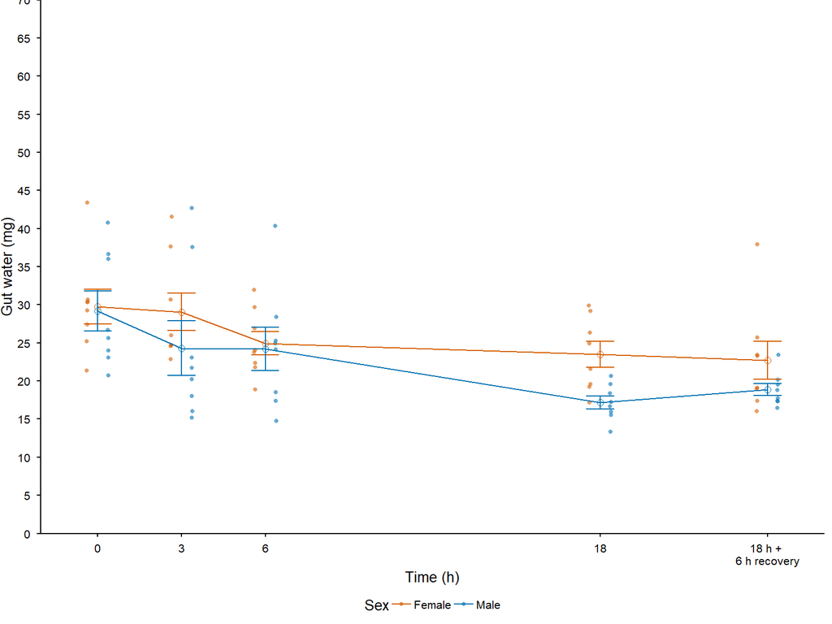

```r
ggplot() +
  geom_point(data = gg_data, aes(Time, gut_water, shape = Sex, colour = Sex), position = position_jitterdodge(jitter.height = 0, jitter.width = 0.1, dodge = 1.5), alpha = 0.6, stroke = NA) +
  geom_line(data = gut_water_mean, aes(Time, mean, colour = Sex), linewidth = 0.5) +
  geom_point(data = gut_water_mean, aes(Time, mean, colour = Sex),
             size = 2, shape = 1, show.legend = FALSE) +
  geom_errorbar(data = gut_water_mean, aes(Time, ymin = mean - se, ymax = mean + se,
                                     colour = Sex), width = 1, linewidth = 0.5) +
  scale_colour_manual(values = sex_pal) +
  scale_shape_manual(values = sex_point) +
  scale_y_continuous(name = "Gut water (mg)", limits = c(0, 70), expand = c(0,0), breaks = seq(0, 150, 5)) +
  scale_x_continuous(name = "Time (h)", breaks = c(0, 3, 6, 18, 24), labels = c("0", "3", "6", "18", "18 h + \n6 h recovery"))
```

```r
gut_water_prop_mean <- gg_data %>%
  group_by(Time, Sex) %>%
  summarise(n = n(),
            mean = mean(gut_water_prop),
            se = sd(gut_water_prop) / sqrt(n()),
            cv = (sd(gut_water_prop) / mean) * 100)
knitr::kable(gut_water_prop_mean, digits = 3)
```

| Time | Sex | n | mean | se | cv |
| --- | --- | --- | --- | --- | --- |
| 0 | Female | 8 | 7.311 | 0.378 | 14.623 |
| 0 | Male | 8 | 12.181 | 1.069 | 24.818 |
| 3 | Female | 8 | 8.629 | 0.832 | 27.276 |
| 3 | Male | 8 | 10.348 | 1.006 | 27.501 |
| 6 | Female | 8 | 7.234 | 0.645 | 25.234 |
| 6 | Male | 8 | 9.539 | 0.675 | 20.006 |
| 18 | Female | 8 | 5.950 | 0.442 | 21.030 |
| 18 | Male | 8 | 7.226 | 0.480 | 18.796 |
| 24 | Female | 8 | 6.043 | 0.560 | 26.217 |
| 24 | Male | 8 | 7.486 | 0.294 | 11.119 |

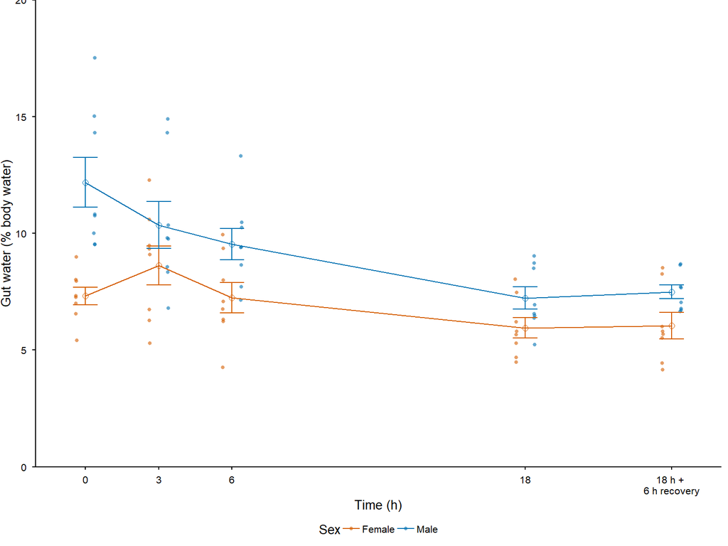

```r
p_gut <- ggplot() +
  geom_point(data = gg_data, aes(Time, gut_water_prop, shape = Sex, colour = Sex), position = position_jitterdodge(jitter.height = 0, jitter.width = 0.1, dodge = 1.5), alpha = 0.6, stroke = NA) +
  geom_line(data = gut_water_prop_mean, aes(Time, mean, colour = Sex), linewidth = 0.5) +
  geom_point(data = gut_water_prop_mean, aes(Time, mean, colour = Sex),
             size = 2, shape = 1, show.legend = FALSE) +
  geom_errorbar(data = gut_water_prop_mean, aes(Time, ymin = mean - se, ymax = mean + se,
                                     colour = Sex), width = 1, linewidth = 0.5) +
  scale_colour_manual(values = sex_pal) +
  scale_shape_manual(values = sex_point) +
  scale_y_continuous(name = "Gut water (% body water)", limits = c(0, 20), expand = c(0,0), breaks = seq(0, 150, 5)) +
  scale_x_continuous(name = "Time (h)", breaks = c(0, 3, 6, 18, 24), labels = c("0", "3", "6", "18", "18 h + \n6 h recovery"))

p_gut
```

```r
gut_mod <- lm(gut_water_prop ~ Time_treatment + Sex, data = gg_data[gg_data$Time_treatment!="0_starved",])

anova(gut_mod)
```

```
Analysis of Variance Table

Response: gut_water_prop
               Df Sum Sq Mean Sq F value      Pr(>F)
Time_treatment  4 139.90  34.975  8.7013 0.000008203 ***
Sex             1 107.89 107.891 26.8421 0.000001843 ***
Residuals      74 297.44   4.019
---
Signif. codes:  0 '***' 0.001 '**' 0.01 '*' 0.05 '.' 0.1 ' ' 1
```

```r
# Compare with 0 starved
emmeans(gut_mod, ~ Time_treatment) %>%
  contrast(method = "trt.vs.ctrl", ref = "0")
```

```
 contrast       estimate    SE df t.ratio p.value
 18 - 0           -3.158 0.709 74  -4.455  0.0001
 24_starved - 0   -2.981 0.709 74  -4.206  0.0003
 3 - 0            -0.257 0.709 74  -0.363  0.9676
 6 - 0            -1.359 0.709 74  -1.917  0.1843

Results are averaged over the levels of: Sex
P value adjustment: dunnettx method for 4 tests
```

```r
emmeans(gut_mod, ~ Time_treatment) %>%
  pairs(adjust = "Tukey")
```

```
 contrast        estimate    SE df t.ratio p.value
 0 - 18             3.158 0.709 74   4.455  0.0003
 0 - 24_starved     2.981 0.709 74   4.206  0.0007
 0 - 3              0.257 0.709 74   0.363  0.9962
 0 - 6              1.359 0.709 74   1.917  0.3173
 18 - 24_starved   -0.177 0.709 74  -0.249  0.9991
 18 - 3            -2.901 0.709 74  -4.092  0.0010
 18 - 6            -1.799 0.709 74  -2.538  0.0933
 24_starved - 3    -2.724 0.709 74  -3.843  0.0023
 24_starved - 6    -1.622 0.709 74  -2.288  0.1602
 3 - 6              1.102 0.709 74   1.554  0.5310

Results are averaged over the levels of: Sex
P value adjustment: tukey method for comparing a family of 5 estimates
```

```r
gut_mod2 <- update(gut_mod, . ~ . - Time_treatment:Sex)
anova(gut_mod2)
```

```
Analysis of Variance Table

Response: gut_water_prop
               Df Sum Sq Mean Sq F value      Pr(>F)
Time_treatment  4 139.90  34.975  8.7013 0.000008203 ***
Sex             1 107.89 107.891 26.8421 0.000001843 ***
Residuals      74 297.44   4.019
---
Signif. codes:  0 '***' 0.001 '**' 0.01 '*' 0.05 '.' 0.1 ' ' 1
```

## 6.1 Relative gut water

```r
gg_data <- gg_data %>%
  mutate(standard_gut_water = ifelse(Sex == "Female",
                                        gut_water/mean(gg_data[gg_data$Sex == "Female" & gg_data$Time == 0,]$gut_water),
                                        gut_water/mean(gg_data[gg_data$Sex == "Male" & gg_data$Time == 0,]$gut_water)))

std_mean_gut <- gg_data %>%
  group_by(Time_treatment, Sex, Time) %>%
  summarise(n = n(),
            mean = mean(standard_gut_water),
            se = sd(standard_gut_water) / sqrt(n()),
            cv = (sd(standard_gut_water) / mean) * 100)
knitr::kable(std_mean_gut, digits = 3)
```

| Time_treatment | Sex | Time | n | mean | se | cv |
| --- | --- | --- | --- | --- | --- | --- |
| 0 | Female | 0 | 8 | 1.000 | 0.076 | 21.450 |
| 0 | Male | 0 | 8 | 1.000 | 0.090 | 25.573 |
| 18 | Female | 18 | 8 | 0.789 | 0.057 | 20.409 |
| 18 | Male | 18 | 8 | 0.588 | 0.029 | 13.753 |
| 24_starved | Female | 24 | 8 | 0.764 | 0.083 | 30.725 |
| 24_starved | Male | 24 | 8 | 0.645 | 0.027 | 11.809 |
| 3 | Female | 3 | 8 | 0.977 | 0.083 | 23.937 |
| 3 | Male | 3 | 8 | 0.832 | 0.124 | 42.015 |
| 6 | Female | 6 | 8 | 0.838 | 0.051 | 17.345 |
| 6 | Male | 6 | 8 | 0.829 | 0.097 | 33.059 |

```r
rel_gut <- ggplot() +
  geom_hline(yintercept = 1, linetype = 3, colour = "grey30") +
  geom_point(data = gg_data, aes(Time, standard_gut_water, shape = Sex, colour = Sex), position = position_jitterdodge(jitter.height = 0, jitter.width = 0.1, dodge = 1.5), alpha = 0.6, stroke = NA) +
   # line for starved crickets
  geom_line(data = std_mean_gut, aes(Time, mean, colour = Sex), linewidth = 0.5) +
  geom_point(data = std_mean_gut, aes(Time, mean, colour = Sex),
             size = 2, shape = 1, show.legend = FALSE) +
  geom_errorbar(data = std_mean_gut, aes(Time, ymin = mean - se, ymax = mean + se,
                                     colour = Sex), width = 1, linewidth = 0.5) +
  scale_colour_manual(values = sex_pal) +
  scale_shape_manual(values = sex_point) +
  scale_y_continuous(name = "Relative gut water", limits = c(0.4, 1.6), expand = c(0,0), breaks = seq(0, 2, 0.2)) +
  scale_x_continuous(name = "Time (h)", breaks = c(0, 3, 6, 18, 24), labels = c("0", "3", "6", "18", "18 h + \n6 h recovery"))

rel_gut_mod <- lm(standard_gut_water ~ Time_treatment + Sex, data = gg_data)
# No interaction
anova(rel_gut_mod)
```

```
Analysis of Variance Table

Response: standard_gut_water
               Df Sum Sq  Mean Sq F value    Pr(>F)
Time_treatment  4 1.1229 0.280734  5.9862 0.0003142 ***
Sex             1 0.1797 0.179685  3.8315 0.0540696 .
Residuals      74 3.4704 0.046897
---
Signif. codes:  0 '***' 0.001 '**' 0.01 '*' 0.05 '.' 0.1 ' ' 1
```

```r
# Compare with 0 starved
emmeans(rel_gut_mod, ~ Time_treatment) %>%
  contrast(method = "trt.vs.ctrl", ref = "0")
```

```
 contrast       estimate     SE df t.ratio p.value
 18 - 0          -0.3114 0.0766 74  -4.068  0.0005
 24_starved - 0  -0.2954 0.0766 74  -3.858  0.0009
 3 - 0           -0.0951 0.0766 74  -1.242  0.5327
 6 - 0           -0.1666 0.0766 74  -2.175  0.1084

Results are averaged over the levels of: Sex
P value adjustment: dunnettx method for 4 tests
```

```r
emmeans(rel_gut_mod, ~ Time_treatment) %>%
  pairs(adjust = "Tukey")
```

```
 contrast        estimate     SE df t.ratio p.value
 0 - 18            0.3114 0.0766 74   4.068  0.0011
 0 - 24_starved    0.2954 0.0766 74   3.858  0.0022
 0 - 3             0.0951 0.0766 74   1.242  0.7270
 0 - 6             0.1666 0.0766 74   2.175  0.2005
 18 - 24_starved  -0.0160 0.0766 74  -0.210  0.9996
 18 - 3           -0.2164 0.0766 74  -2.826  0.0464
 18 - 6           -0.1449 0.0766 74  -1.892  0.3305
 24_starved - 3   -0.2003 0.0766 74  -2.616  0.0777
 24_starved - 6   -0.1288 0.0766 74  -1.683  0.4508
 3 - 6             0.0715 0.0766 74   0.933  0.8830

Results are averaged over the levels of: Sex
P value adjustment: tukey method for comparing a family of 5 estimates
```

# 7 Gonad

```r
gonad_water_mean <- gg_data %>%
  group_by(Time, Sex) %>%
  summarise(n = n(),
            mean = mean(gonad_water),
            se = sd(gonad_water) / sqrt(n()),
            cv = (sd(gonad_water) / mean) * 100)
knitr::kable(gonad_water_mean, digits = 3)
```

| Time | Sex | n | mean | se | cv |
| --- | --- | --- | --- | --- | --- |
| 0 | Female | 8 | 109.996 | 8.792 | 22.608 |
| 0 | Male | 8 | 23.396 | 1.194 | 14.432 |
| 3 | Female | 8 | 80.964 | 14.454 | 50.495 |
| 3 | Male | 8 | 25.064 | 1.907 | 21.519 |
| 6 | Female | 8 | 79.245 | 7.823 | 27.922 |
| 6 | Male | 8 | 27.330 | 1.358 | 14.050 |
| 18 | Female | 8 | 82.778 | 9.230 | 31.539 |
| 18 | Male | 8 | 24.140 | 2.231 | 26.134 |
| 24 | Female | 8 | 81.914 | 9.812 | 33.882 |
| 24 | Male | 8 | 25.027 | 1.360 | 15.368 |

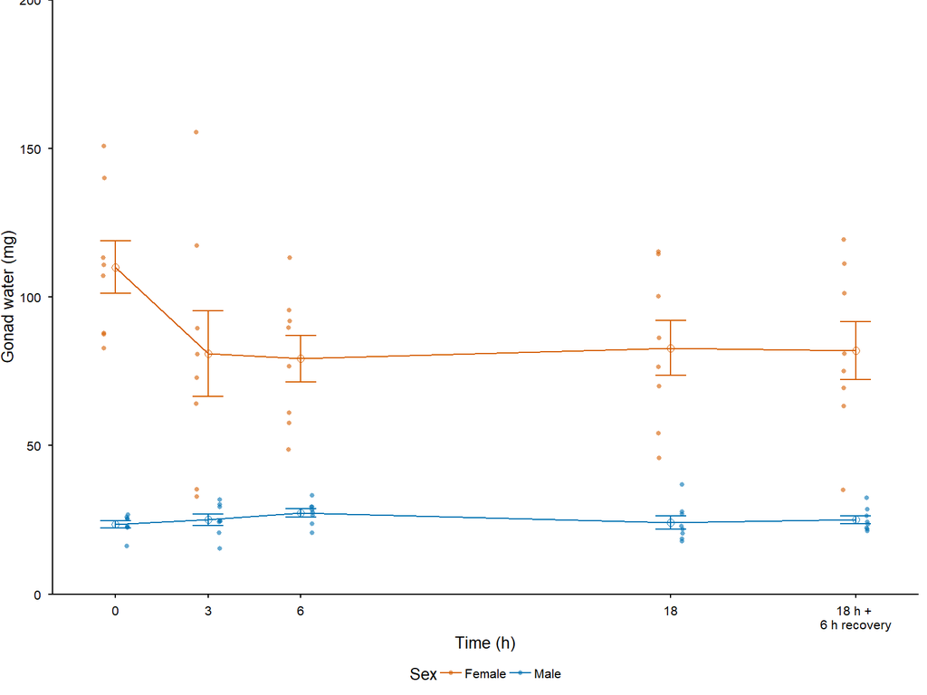

```r
ggplot() +
  geom_point(data = gg_data, aes(Time, gonad_water, shape = Sex, colour = Sex), position = position_jitterdodge(jitter.height = 0, jitter.width = 0.1, dodge = 1.5), alpha = 0.6, stroke = NA) +
  geom_line(data = gonad_water_mean, aes(Time, mean, colour = Sex), linewidth = 0.5) +
  geom_point(data = gonad_water_mean, aes(Time, mean, colour = Sex),
             size = 2, shape = 1, show.legend = FALSE) +
  geom_errorbar(data = gonad_water_mean, aes(Time, ymin = mean - se, ymax = mean + se,
                                     colour = Sex), width = 1, linewidth = 0.5) +
  scale_colour_manual(values = sex_pal) +
  scale_shape_manual(values = sex_point) +
  scale_y_continuous(name = "Gonad water (mg)", limits = c(0, 200), expand = c(0,0), breaks = seq(0, 200, 50)) +
  scale_x_continuous(name = "Time (h)", breaks = c(0, 3, 6, 18, 24), labels = c("0", "3", "6", "18", "18 h + \n6 h recovery"))
```

```r
gonad_prop_mean <- gg_data %>%
  group_by(Time, Sex) %>%
  summarise(n = n(),
            mean = mean(gonad_water_prop),
            se = sd(gonad_water_prop) / sqrt(n()),
            cv = (sd(gonad_water_prop) / mean) * 100)
knitr::kable(gonad_prop_mean, digits = 3)
```

| Time | Sex | n | mean | se | cv |
| --- | --- | --- | --- | --- | --- |
| 0 | Female | 8 | 26.921 | 1.297 | 13.623 |
| 0 | Male | 8 | 9.868 | 0.738 | 21.163 |
| 3 | Female | 8 | 22.090 | 2.492 | 31.909 |
| 3 | Male | 8 | 10.948 | 0.613 | 15.846 |
| 6 | Female | 8 | 22.033 | 1.130 | 14.503 |
| 6 | Male | 8 | 11.048 | 0.489 | 12.527 |
| 18 | Female | 8 | 20.573 | 1.772 | 24.365 |
| 18 | Male | 8 | 9.902 | 0.472 | 13.489 |
| 24 | Female | 8 | 21.460 | 2.105 | 27.745 |
| 24 | Male | 8 | 9.963 | 0.554 | 15.735 |

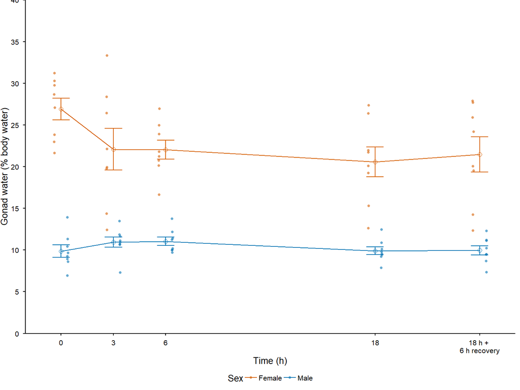

```r
p_gonad <- ggplot() +
  geom_point(data = gg_data, aes(Time, gonad_water_prop, shape = Sex, colour = Sex), position = position_jitterdodge(jitter.height = 0, jitter.width = 0.1, dodge = 1.5), alpha = 0.6, stroke = NA) +
  geom_line(data = gonad_prop_mean, aes(Time, mean, colour = Sex), linewidth = 0.5) +
  geom_point(data = gonad_prop_mean, aes(Time, mean, colour = Sex),
             size = 2, shape = 1, show.legend = FALSE) +
  geom_errorbar(data = gonad_prop_mean, aes(Time, ymin = mean - se, ymax = mean + se,
                                     colour = Sex), width = 1, linewidth = 0.5) +
  scale_colour_manual(values = sex_pal) +
  scale_shape_manual(values = sex_point) +
  scale_y_continuous(name = "Gonad water (% body water)", limits = c(0, 40), expand = c(0,0), breaks = seq(0, 150, 5)) +
  scale_x_continuous(name = "Time (h)", breaks = c(0, 3, 6, 18, 24), labels = c("0", "3", "6", "18", "18 h + \n6 h recovery"))

p_gonad
```

No change in gonads. No interaction

```r
gonad_mod <- lm(gonad_water_prop ~ Time_treatment + Sex, data = gg_data[gg_data$Time_treatment!="0_starved",])

anova(gonad_mod)
```

```
Analysis of Variance Table

Response: gonad_water_prop
               Df  Sum Sq Mean Sq  F value              Pr(>F)
Time_treatment  4   92.88   23.22   1.4968              0.2119
Sex             1 3010.85 3010.85 194.0843 <0.0000000000000002 ***
Residuals      74 1147.97   15.51
---
Signif. codes:  0 '***' 0.001 '**' 0.01 '*' 0.05 '.' 0.1 ' ' 1
```

```r
pairs(emmeans(gonad_mod, ~ Time_treatment * Sex), adjust = "Tukey", by = "Sex") %>%
  broom::tidy()
```

```
# A tibble: 20 × 9
   Sex    term           contrast        null.value    estimate std.error    df
   <chr>  <chr>          <chr>                <dbl>       <dbl>     <dbl> <dbl>
 1 Female Time_treatment 0 - 18                   0  3.157078    1.392528    74
 2 Female Time_treatment 0 - 24_starved           0  2.683029    1.392528    74
 3 Female Time_treatment 0 - 3                    0  1.875341    1.392528    74
 4 Female Time_treatment 0 - 6                    0  1.854304    1.392528    74
 5 Female Time_treatment 18 - 24_starved          0 -0.4740492   1.392528    74
 6 Female Time_treatment 18 - 3                   0 -1.281738    1.392528    74
 7 Female Time_treatment 18 - 6                   0 -1.302774    1.392528    74
 8 Female Time_treatment 24_starved - 3           0 -0.8076884   1.392528    74
 9 Female Time_treatment 24_starved - 6           0 -0.8287250   1.392528    74
10 Female Time_treatment 3 - 6                    0 -0.02103659  1.392528    74
11 Male   Time_treatment 0 - 18                   0  3.157078    1.392528    74
12 Male   Time_treatment 0 - 24_starved           0  2.683029    1.392528    74
```

[output cut: 30 more lines]

```r
gonad_mod2 <- update(gonad_mod, . ~ . - Time_treatment:Sex)
anova(gonad_mod2)
```

```
Analysis of Variance Table

Response: gonad_water_prop
               Df  Sum Sq Mean Sq  F value              Pr(>F)
Time_treatment  4   92.88   23.22   1.4968              0.2119
Sex             1 3010.85 3010.85 194.0843 <0.0000000000000002 ***
Residuals      74 1147.97   15.51
---
Signif. codes:  0 '***' 0.001 '**' 0.01 '*' 0.05 '.' 0.1 ' ' 1
```

## 7.1 Relative gonad water

```r
gg_data <- gg_data %>%
  mutate(standard_gonad_water = ifelse(Sex == "Female",
                                        gonad_water/mean(gg_data[gg_data$Sex == "Female" & gg_data$Time == 0,]$gonad_water),
                                        gonad_water/mean(gg_data[gg_data$Sex == "Male" & gg_data$Time == 0,]$gonad_water)))

std_mean_gonad <- gg_data %>%
  group_by(Time_treatment, Sex, Time) %>%
  summarise(n = n(),
            mean = mean(standard_gonad_water),
            se = sd(standard_gonad_water) / sqrt(n()),
            cv = (sd(standard_gonad_water) / mean) * 100)
knitr::kable(std_mean_gonad, digits = 3)
```

| Time_treatment | Sex | Time | n | mean | se | cv |
| --- | --- | --- | --- | --- | --- | --- |
| 0 | Female | 0 | 8 | 1.000 | 0.080 | 22.608 |
| 0 | Male | 0 | 8 | 1.000 | 0.051 | 14.432 |
| 18 | Female | 18 | 8 | 0.753 | 0.084 | 31.539 |
| 18 | Male | 18 | 8 | 1.032 | 0.095 | 26.134 |
| 24_starved | Female | 24 | 8 | 0.745 | 0.089 | 33.882 |
| 24_starved | Male | 24 | 8 | 1.070 | 0.058 | 15.368 |
| 3 | Female | 3 | 8 | 0.736 | 0.131 | 50.495 |
| 3 | Male | 3 | 8 | 1.071 | 0.082 | 21.519 |
| 6 | Female | 6 | 8 | 0.720 | 0.071 | 27.922 |
| 6 | Male | 6 | 8 | 1.168 | 0.058 | 14.050 |

```r
rel_gonad <- ggplot() +
  geom_hline(yintercept = 1, linetype = 3, colour = "grey30") +
  geom_point(data = gg_data, aes(Time, standard_gonad_water, shape = Sex, colour = Sex), position = position_jitterdodge(jitter.height = 0, jitter.width = 0.1, dodge = 1.5), alpha = 0.6, stroke = NA) +
   # line for starved crickets
  geom_line(data = std_mean_gonad, aes(Time, mean, colour = Sex), linewidth = 0.5) +
  geom_point(data = std_mean_gonad, aes(Time, mean, colour = Sex),
             size = 2, shape = 1, show.legend = FALSE) +
  geom_errorbar(data = std_mean_gonad, aes(Time, ymin = mean - se, ymax = mean + se,
                                     colour = Sex), width = 1, linewidth = 0.5) +
  scale_colour_manual(values = sex_pal) +
  scale_shape_manual(values = sex_point) +
  scale_y_continuous(name = "Relative gonad water", limits = c(0.2, 1.6), expand = c(0,0), breaks = seq(-100, 100, 0.2)) +
  scale_x_continuous(name = "Time (h)", breaks = c(0, 3, 6, 18, 24), labels = c("0", "3", "6", "18", "18 h + \n6 h recovery"))

rel_gonad_mod <- lm(standard_gonad_water ~ Time_treatment + Sex, data = gg_data)
# No interaction
anova(rel_gonad_mod)
```

```
Analysis of Variance Table

Response: standard_gonad_water
               Df Sum Sq Mean Sq F value    Pr(>F)
Time_treatment  4 0.1240 0.03099  0.5335    0.7115
Sex             1 1.5393 1.53933 26.4984 0.0000021 ***
Residuals      74 4.2988 0.05809
---
Signif. codes:  0 '***' 0.001 '**' 0.01 '*' 0.05 '.' 0.1 ' ' 1
```

```r
# Compare with 0 starved
emmeans(rel_gonad_mod, ~ Time_treatment) %>%
  contrast(method = "trt.vs.ctrl", ref = "0")
```

```
 contrast       estimate     SE df t.ratio p.value
 18 - 0          -0.1078 0.0852 74  -1.265  0.5178
 24_starved - 0  -0.0928 0.0852 74  -1.089  0.6300
 3 - 0           -0.0963 0.0852 74  -1.131  0.6036
 6 - 0           -0.0557 0.0852 74  -0.654  0.8730

Results are averaged over the levels of: Sex
P value adjustment: dunnettx method for 4 tests
```

```r
emmeans(rel_gonad_mod, ~ Time_treatment) %>%
  pairs(adjust = "Tukey")
```

```
 contrast        estimate     SE df t.ratio p.value
 0 - 18           0.10784 0.0852 74   1.265  0.7130
 0 - 24_starved   0.09280 0.0852 74   1.089  0.8116
 0 - 3            0.09634 0.0852 74   1.131  0.7899
 0 - 6            0.05572 0.0852 74   0.654  0.9654
 18 - 24_starved -0.01503 0.0852 74  -0.176  0.9998
 18 - 3          -0.01150 0.0852 74  -0.135  0.9999
 18 - 6          -0.05212 0.0852 74  -0.612  0.9728
 24_starved - 3   0.00354 0.0852 74   0.042  1.0000
 24_starved - 6  -0.03708 0.0852 74  -0.435  0.9924
 3 - 6           -0.04062 0.0852 74  -0.477  0.9892

Results are averaged over the levels of: Sex
P value adjustment: tukey method for comparing a family of 5 estimates
```

```r
gg_data <- mutate(gg_data, goand_pc = ((wet_gonad_mass - dry_gonad_mass) /wet_gonad_mass) *100)

anova(lm(goand_pc ~ Time + Sex, gg_data))
```

```
Analysis of Variance Table

Response: goand_pc
          Df  Sum Sq Mean Sq   F value              Pr(>F)
Time       1     2.6     2.6    0.9116              0.3427
Sex        1 14852.6 14852.6 5223.9249 <0.0000000000000002 ***
Residuals 77   218.9     2.8
---
Signif. codes:  0 '***' 0.001 '**' 0.01 '*' 0.05 '.' 0.1 ' ' 1
```

```r
gg_data |>
  group_by( Sex) |>
  summarise(goand_pc_me = mean(goand_pc,na.rm = T),
            goand_pcse = sd(goand_pc,na.rm = T)/sqrt(n()))
```

```
# A tibble: 2 × 3
  Sex    goand_pc_me goand_pcse
  <chr>        <dbl>      <dbl>
1 Female    48.75769  0.2731478
2 Male      76.00889  0.2595921
```

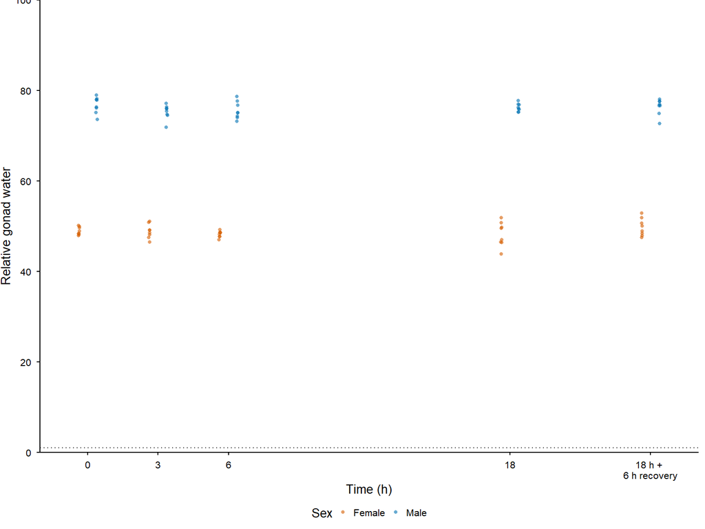

```r
ggplot() +
  geom_hline(yintercept = 1, linetype = 3, colour = "grey30") +
  geom_point(data = gg_data, aes(Time, goand_pc, shape = Sex, colour = Sex), position = position_jitterdodge(jitter.height = 0, jitter.width = 0.1, dodge = 1.5), alpha = 0.6, stroke = NA) +
   # line for starved crickets
  scale_colour_manual(values = sex_pal) +
  scale_shape_manual(values = sex_point) +
  scale_y_continuous(name = "Relative gonad water", limits = c(0, 100), expand = c(0,0), breaks = seq(-100, 100, 20)) +
  scale_x_continuous(name = "Time (h)", breaks = c(0, 3, 6, 18, 24), labels = c("0", "3", "6", "18", "18 h + \n6 h recovery"))
```

# 8 Haemolymph

```r
haem_water_mean <- gg_data %>%
  group_by(Time, Sex) %>%
  summarise(n = n(),
            mean = mean(haem_water),
            se = sd(haem_water) / sqrt(n()),
            cv = (sd(haem_water) / mean) * 100)
knitr::kable(haem_water_mean, digits = 3)
```

| Time | Sex | n | mean | se | cv |
| --- | --- | --- | --- | --- | --- |
| 0 | Female | 8 | 100.373 | 7.499 | 21.131 |
| 0 | Male | 8 | 60.727 | 3.806 | 17.725 |
| 3 | Female | 8 | 75.471 | 5.546 | 20.784 |
| 3 | Male | 8 | 44.693 | 2.482 | 15.708 |
| 6 | Female | 8 | 89.939 | 7.350 | 23.116 |
| 6 | Male | 8 | 51.959 | 2.279 | 12.405 |
| 18 | Female | 8 | 81.803 | 7.261 | 25.105 |
| 18 | Male | 8 | 39.849 | 4.127 | 29.294 |
| 24 | Female | 8 | 82.660 | 6.086 | 20.824 |
| 24 | Male | 8 | 44.328 | 4.468 | 28.511 |

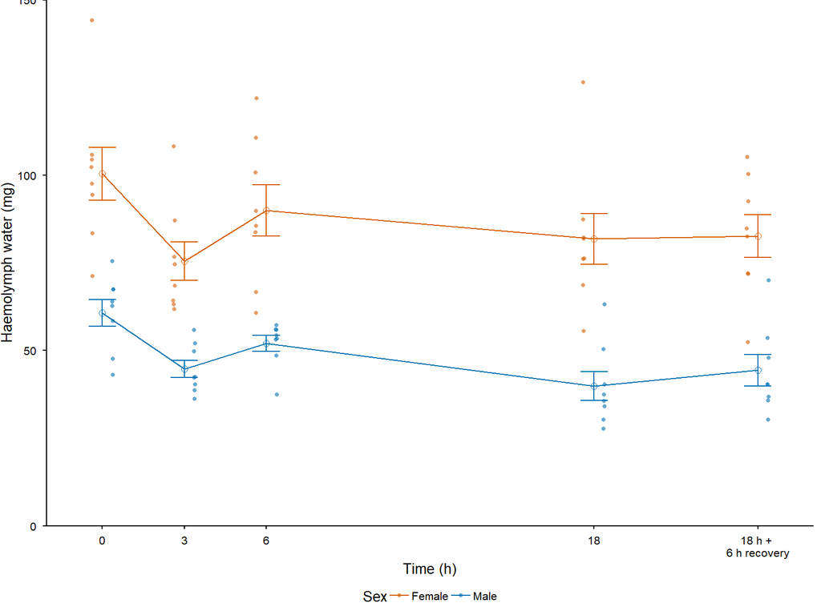

```r
ggplot() +
  geom_point(data = gg_data, aes(Time, haem_water, shape = Sex, colour = Sex), position = position_jitterdodge(jitter.height = 0, jitter.width = 0.1, dodge = 1.5), alpha = 0.6, stroke = NA) +
  geom_line(data = haem_water_mean, aes(Time, mean, colour = Sex), linewidth = 0.5) +
  geom_point(data = haem_water_mean, aes(Time, mean, colour = Sex),
             size = 2, shape = 1, show.legend = FALSE) +
  geom_errorbar(data = haem_water_mean, aes(Time, ymin = mean - se, ymax = mean + se,
                                     colour = Sex), width = 1, linewidth = 0.5) +
  scale_colour_manual(values = sex_pal) +
  scale_shape_manual(values = sex_point) +
  scale_y_continuous(name = "Haemolymph water (mg)", limits = c(0, 150), expand = c(0,0), breaks = seq(0, 200, 50)) +
  scale_x_continuous(name = "Time (h)", breaks = c(0, 3, 6, 18, 24), labels = c("0", "3", "6", "18", "18 h + \n6 h recovery"))
```

```r
haem_water_prop_mean <- gg_data %>%
  group_by(Time, Sex) %>%
  summarise(n = n(),
            mean = mean(haem_water_prop),
            se = sd(haem_water_prop) / sqrt(n()),
            cv = (sd(haem_water_prop) / mean) * 100)
knitr::kable(haem_water_prop_mean, digits = 3)
```

| Time | Sex | n | mean | se | cv |
| --- | --- | --- | --- | --- | --- |
| 0 | Female | 8 | 24.683 | 1.325 | 15.180 |
| 0 | Male | 8 | 25.195 | 1.131 | 12.693 |
| 3 | Female | 8 | 22.095 | 1.491 | 19.091 |
| 3 | Male | 8 | 19.655 | 0.914 | 13.146 |
| 6 | Female | 8 | 25.320 | 1.351 | 15.091 |
| 6 | Male | 8 | 21.053 | 0.997 | 13.394 |
| 18 | Female | 8 | 20.652 | 1.476 | 20.218 |
| 18 | Male | 8 | 16.861 | 2.067 | 34.677 |
| 24 | Female | 8 | 21.922 | 1.259 | 16.250 |
| 24 | Male | 8 | 17.324 | 1.161 | 18.955 |

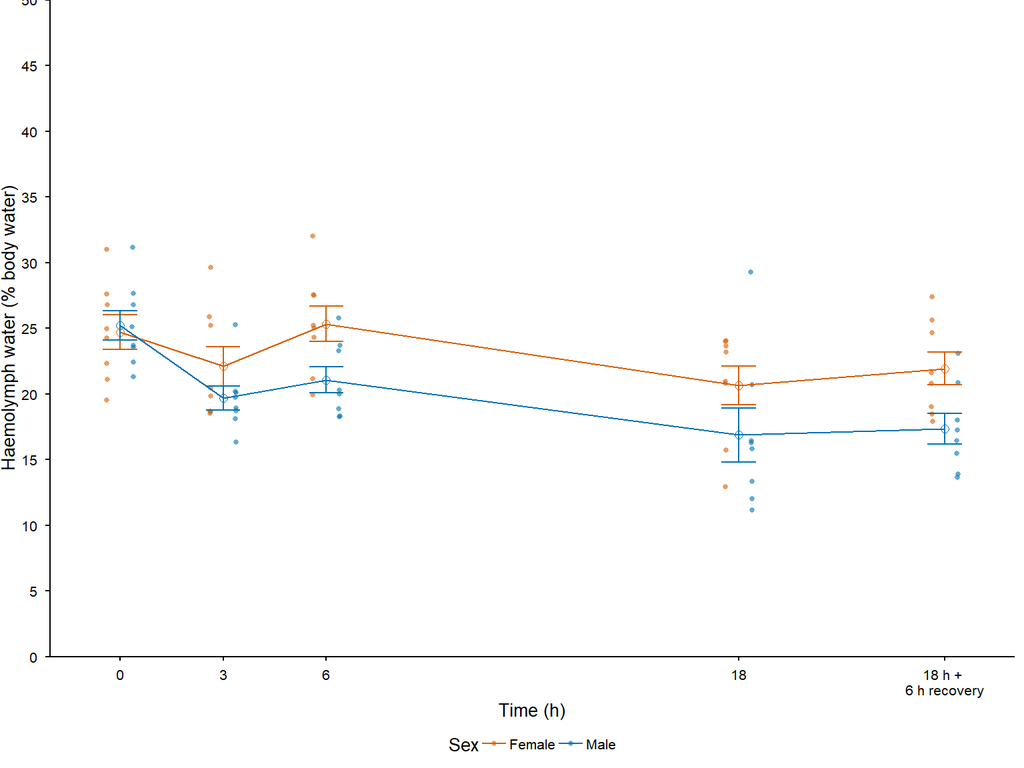

```r
p_haem <- ggplot() +
  geom_point(data = gg_data, aes(Time, haem_water_prop, shape = Sex, colour = Sex), position = position_jitterdodge(jitter.height = 0, jitter.width = 0.1, dodge = 1.5), alpha = 0.6, stroke = NA) +
  geom_line(data = haem_water_prop_mean, aes(Time, mean, colour = Sex), linewidth = 0.5) +
  geom_point(data = haem_water_prop_mean, aes(Time, mean, colour = Sex),
             size = 2, shape = 1, show.legend = FALSE) +
  geom_errorbar(data = haem_water_prop_mean, aes(Time, ymin = mean - se, ymax = mean + se,
                                     colour = Sex), width = 1, linewidth = 0.5) +
  scale_colour_manual(values = sex_pal) +
  scale_shape_manual(values = sex_point) +
  scale_y_continuous(name = "Haemolymph water (% body water)", limits = c(0, 50), expand = c(0,0), breaks = seq(0, 150, 5)) +
  scale_x_continuous(name = "Time (h)", breaks = c(0, 3, 6, 18, 24), labels = c("0", "3", "6", "18", "18 h + \n6 h recovery"))

p_haem
```

No interaction.

```r
haem_mod <- lm(haem_water_prop ~ Time_treatment * Sex, data = gg_data)

anova(haem_mod)
```

```
Analysis of Variance Table

Response: haem_water_prop
                   Df  Sum Sq Mean Sq F value     Pr(>F)
Time_treatment      4  417.78 104.445  7.1351 0.00007059 ***
Sex                 1  170.11 170.106 11.6207   0.001086 **
Time_treatment:Sex  4   69.59  17.397  1.1884   0.323518
Residuals          70 1024.67  14.638
---
Signif. codes:  0 '***' 0.001 '**' 0.01 '*' 0.05 '.' 0.1 ' ' 1
```

```r
pairs(emmeans(haem_mod, ~ Time_treatment * Sex), adjust = "Tukey", by = "Sex") %>%
  broom::tidy()
```

```
# A tibble: 20 × 9
   Sex    term           contrast        null.value   estimate std.error    df
   <chr>  <chr>          <chr>                <dbl>      <dbl>     <dbl> <dbl>
 1 Female Time_treatment 0 - 18                   0  4.031280   1.912994    70
 2 Female Time_treatment 0 - 24_starved           0  2.761265   1.912994    70
 3 Female Time_treatment 0 - 3                    0  2.588005   1.912994    70
 4 Female Time_treatment 0 - 6                    0 -0.6369642  1.912994    70
 5 Female Time_treatment 18 - 24_starved          0 -1.270015   1.912994    70
 6 Female Time_treatment 18 - 3                   0 -1.443275   1.912994    70
 7 Female Time_treatment 18 - 6                   0 -4.668244   1.912994    70
 8 Female Time_treatment 24_starved - 3           0 -0.1732599  1.912994    70
 9 Female Time_treatment 24_starved - 6           0 -3.398229   1.912994    70
10 Female Time_treatment 3 - 6                    0 -3.224969   1.912994    70
11 Male   Time_treatment 0 - 18                   0  8.333978   1.912994    70
12 Male   Time_treatment 0 - 24_starved           0  7.871417   1.912994    70
```

[output cut: 30 more lines]

```r
haem_mod2 <- update(haem_mod, . ~ . - Time_treatment:Sex)
anova(haem_mod2)
```

```
Analysis of Variance Table

Response: haem_water_prop
               Df  Sum Sq Mean Sq F value     Pr(>F)
Time_treatment  4  417.78 104.445  7.0631 0.00007141 ***
Sex             1  170.11 170.106 11.5035   0.001118 **
Residuals      74 1094.26  14.787
---
Signif. codes:  0 '***' 0.001 '**' 0.01 '*' 0.05 '.' 0.1 ' ' 1
```

```r
pairs(emmeans(haem_mod2, ~ Time_treatment), adjust = "Tukey") %>%
  broom::tidy()
```

```
# A tibble: 10 × 8
   term           contrast        null.value   estimate std.error    df
   <chr>          <chr>                <dbl>      <dbl>     <dbl> <dbl>
 1 Time_treatment 0 - 18                   0  6.182629   1.359563    74
 2 Time_treatment 0 - 24_starved           0  5.316341   1.359563    74
 3 Time_treatment 0 - 3                    0  4.064142   1.359563    74
 4 Time_treatment 0 - 6                    0  1.752403   1.359563    74
 5 Time_treatment 18 - 24_starved          0 -0.8662877  1.359563    74
 6 Time_treatment 18 - 3                   0 -2.118486   1.359563    74
 7 Time_treatment 18 - 6                   0 -4.430226   1.359563    74
 8 Time_treatment 24_starved - 3           0 -1.252199   1.359563    74
 9 Time_treatment 24_starved - 6           0 -3.563938   1.359563    74
10 Time_treatment 3 - 6                    0 -2.311739   1.359563    74
    statistic  adj.p.value
        <dbl>        <dbl>
 1  4.547512  0.0001976280
 2  3.910331  0.001844467
 3  2.989301  0.03017784
 4  1.288946  0.6987706
 5 -0.6371811 0.9684725
 6 -1.558211  0.5286203
 7 -3.258566  0.01418789
 8 -0.9210303 0.8879076
 9 -2.621385  0.07676345
10 -1.700355  0.4400667
```

## 8.1 Relative haemolymph water

```r
gg_data <- gg_data %>%
  mutate(standard_haem_water = ifelse(Sex == "Female",
                                        haem_water/mean(gg_data[gg_data$Sex == "Female" & gg_data$Time == 0,]$haem_water),
                                        haem_water/mean(gg_data[gg_data$Sex == "Male" & gg_data$Time == 0,]$haem_water)))

std_mean_haem <- gg_data %>%
  group_by(Time_treatment, Sex, Time) %>%
  summarise(n = n(),
            mean = mean(standard_haem_water),
            se = sd(standard_haem_water) / sqrt(n()),
            cv = (sd(standard_haem_water) / mean) * 100)
knitr::kable(std_mean_haem, digits = 3)
```

| Time_treatment | Sex | Time | n | mean | se | cv |
| --- | --- | --- | --- | --- | --- | --- |
| 0 | Female | 0 | 8 | 1.000 | 0.075 | 21.131 |
| 0 | Male | 0 | 8 | 1.000 | 0.063 | 17.725 |
| 18 | Female | 18 | 8 | 0.815 | 0.072 | 25.105 |
| 18 | Male | 18 | 8 | 0.656 | 0.068 | 29.294 |
| 24_starved | Female | 24 | 8 | 0.824 | 0.061 | 20.824 |
| 24_starved | Male | 24 | 8 | 0.730 | 0.074 | 28.511 |
| 3 | Female | 3 | 8 | 0.752 | 0.055 | 20.784 |
| 3 | Male | 3 | 8 | 0.736 | 0.041 | 15.708 |
| 6 | Female | 6 | 8 | 0.896 | 0.073 | 23.116 |
| 6 | Male | 6 | 8 | 0.856 | 0.038 | 12.405 |

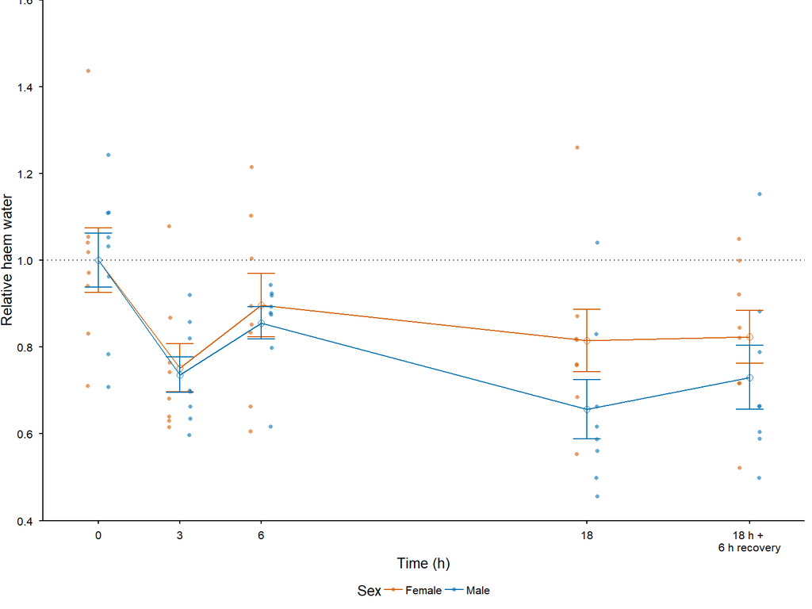

```r
rel_haem <- ggplot() +
  geom_hline(yintercept = 1, linetype = 3, colour = "grey30") +
  geom_point(data = gg_data, aes(Time, standard_haem_water, shape = Sex, colour = Sex), position = position_jitterdodge(jitter.height = 0, jitter.width = 0.1, dodge = 1.5), alpha = 0.6, stroke = NA) +
   # line for starved crickets
  geom_line(data = std_mean_haem, aes(Time, mean, colour = Sex), linewidth = 0.5) +
  geom_point(data = std_mean_haem, aes(Time, mean, colour = Sex),
             size = 2, shape = 1, show.legend = FALSE) +
  geom_errorbar(data = std_mean_haem, aes(Time, ymin = mean - se, ymax = mean + se,
                                     colour = Sex), width = 1, linewidth = 0.5) +
  scale_colour_manual(values = sex_pal) +
  scale_shape_manual(values = sex_point) +
  scale_y_continuous(name = "Relative haem water", limits = c(0.4, 1.6), expand = c(0,0), breaks = seq(0, 2, 0.2)) +
  scale_x_continuous(name = "Time (h)", breaks = c(0, 3, 6, 18, 24), labels = c("0", "3", "6", "18", "18 h + \n6 h recovery"))
rel_haem
```

# 9 Figure

```r
load("data/Desiccation 2025/figures/p_relwater.rdata")

p_tissuewater <- p_relwater + (p_gut + theme(legend.position = "none")) +
  (p_gonad + theme(legend.position = "none"))  +
  (p_carcass + theme(legend.position = "none")) +
  plot_layout(axis_titles = "collect" , guides = "collect") &
  plot_annotation(tag_levels = 'A')

ggsave(p_tissuewater, dpi = 300, width = double_width, units = "mm", height = double_height, filename = "data/Desiccation 2025/figures/Fig4tissue_water.png")

load("data/Desiccation 2025/figures/p_diffwater.rdata")

p_rel_tissuewater <- p_diff_tissues + (rel_gut + theme(legend.position = "none")) +
  (rel_gonad + theme(legend.position = "none"))  +
  (rel_carcass + theme(legend.position = "none")) +
  plot_layout(axis_titles = "collect" , guides = "collect") &
  plot_annotation(tag_levels = 'A') & theme(legend.title.position = "top")

ggsave(p_rel_tissuewater, dpi = 300, width = double_width, units = "mm", height = double_height, filename = "data/Desiccation 2025/figures/Fig4rel_tissue_water.png")


 p_diffwatertissue <- p_diff_water + (p_diff_tissues + theme(panel.spacing = unit(0.5, "lines"))) +
   guide_area() +
  plot_layout(guides = "collect", heights = c(1,2, 0.5)) & theme( legend.title.position = "top", legend.direction="vertical" ,legend.margin = margin(30, 0, 0, 0), legend.key.spacing.y = unit(-0.1, 'cm'), legend.position = "bottom") &  plot_annotation(tag_levels = 'A')

ggsave(p_diffwatertissue, dpi = 300, width = single_width, units = "mm", height = 170, filename = "data/Desiccation 2025/figures/diff_tissue_water.png")
```